# Report COVID study POOLED V100

Thijs de Boer

2021

Last update: 2021-03-11 14:18:23

```r
load("C:/Users/Thijs/surfdrive/COVID vaccine/git/POOLED/.RData")

set_theme(
  base=theme_blank(),
  geom.outline.size = 0.01,
  geom.outline.color = "white",
  geom.label.size = 3,
  geom.label.color = "grey50")
```

# 1 Population

Total number of cases, final cases, and removed cases (complete cases only):

```r
t1 <- df.total %>% filter(Finished == 1) %>%
  group_by(country) %>%
  tally() %>%
  mutate(percentage = (n/nrow(df.total %>% filter(Finished == 1))*100)) %>%
  adorn_totals("row")

t2 <- pooled  %>% filter(Finished == 1) %>%
  group_by(country) %>%
  tally() %>%
  mutate(percentage = (n/nrow(pooled %>% filter(Finished == 1))*100)) %>%
  adorn_totals("row")

t3 <- merge(x = t1, y = t2, by = "country", all.x = TRUE) %>%  mutate(n.diff = (n.x-n.y),
        percentage.diff = (n.diff/(sum(n.diff/2))*100),
        ratio = (n.y/n.x))

t3 %>%
  kable(col.names = c("",
                      "n",
                      "%",
                      "n",
                      "%",
                      "n",
                      "%",
                      "Ratio (final/total)"
                      ),
        digits = 2,
        align=rep('c', 5)) %>%
    kable_styling(bootstrap_options = c( "condensed",  "striped", "hover"),
                full_width = F,
                position = "left")  %>% add_header_above(c(" ", "Total"  = 2, "Final" = 2, "Failed IMC or under 18" = 2, " "))  %>%
   column_spec(column = 2:8, width = "2cm")
```

|  | Total n | Total % | Final n | Final % | Failed IMC or under 18 n | Failed IMC or under 18 % | Ratio (final/total) |
| --- | --- | --- | --- | --- | --- | --- | --- |
| FR | 1233 | 20.83 | 969 | 21.21 | 264 | 19.57 | 0.79 |
| IE | 1143 | 19.31 | 938 | 20.53 | 205 | 15.20 | 0.82 |
| NL | 1729 | 29.22 | 1285 | 28.12 | 444 | 32.91 | 0.74 |
| SE | 1813 | 30.64 | 1377 | 30.14 | 436 | 32.32 | 0.76 |
| Total | 5918 | 100.00 | 4569 | 100.00 | 1349 | 100.00 | 0.77 |

Number of participants in the final dataset that failed the comprehension check (complete cases only):

```r
t4 <- pooled %>%  filter(Finished == 1) %>%
   group_by(country, comprehension.check.failed)%>%
  summarise(n=n()) %>%
  spread(comprehension.check.failed, n) %>%
  adorn_totals("row")  %>% mutate(
   missing =  `<NA>`,
   missing = tidyr::replace_na(missing, 0),
   total = (failed + passed + missing),
  percentage = (passed/(total)*100) %>% round(2)) %>% relocate(failed, .after = passed)

t4 %>% select(-`<NA>`) %>%
  kable(col.names = c("",
                      "Passed",
                      "Failed",
                      "Missing",
                      "Total",
                      "% Passed")) %>%
    kable_styling(bootstrap_options = c("condensed", "striped", "hover"),
                full_width = F,
                position = "left")
```

|  | Passed | Failed | Missing | Total | % Passed |
| --- | --- | --- | --- | --- | --- |
| FR | 536 | 433 | 0 | 969 | 55.31 |
| IE | 574 | 364 | 0 | 938 | 61.19 |
| NL | 713 | 509 | 63 | 1285 | 55.49 |
| SE | 844 | 533 | 0 | 1377 | 61.29 |
| Total | 2667 | 1839 | 63 | 4569 | 58.37 |

# 2 Outcome variables

In this section we provide additional details about our outcome variables – the three aspects of policy credibility. We report the distributions and correlations of the six survey items. Thereafter, we include the R code and results of our confirmatory factor analysis.

## 2.1 Distributions of items

Item 1: I believe that the EMA’s opinion was based strictly on scientific considerations.

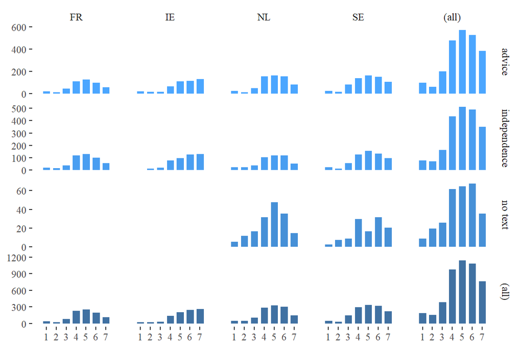

```r
pooled %>%
  ggplot(aes(x=credibility.item1, fill = experimental.group)) +
  geom_bar(width = 0.75, alpha=0.8)+
  scale_x_continuous(name="",limits = c(0,8),breaks = 1:7)+
  scale_fill_manual(values = c("dodgerblue1", "dodgerblue2","dodgerblue3", "dodgerblue4"))+
  facet_grid(experimental.group ~ country,  margins=TRUE, scale="free") +
  theme_tufte() +
  theme(legend.position = "none", axis.title = element_blank())
```

Item 2: I believe that the EMA’s opinion was influenced by political interests. (reversed)

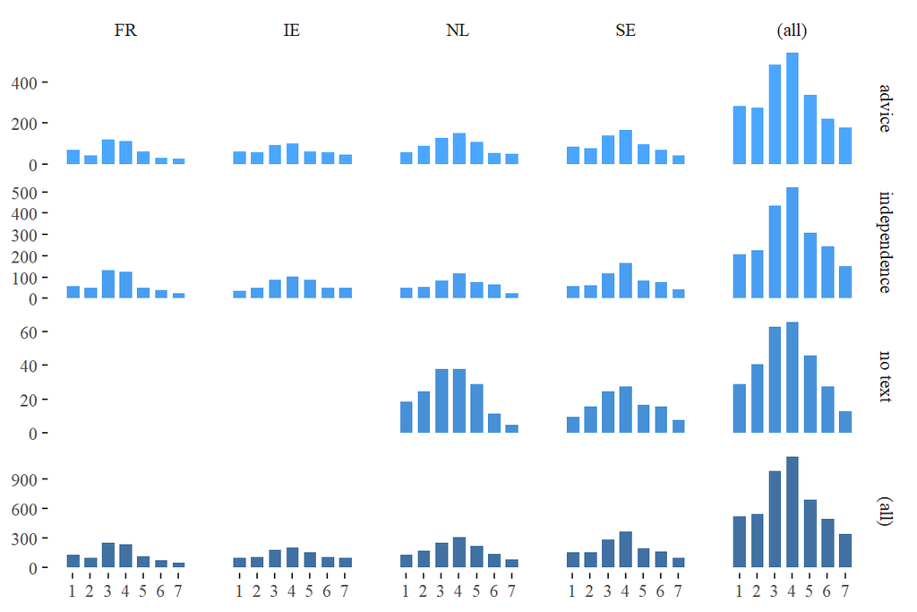

```r
pooled %>%
  ggplot(aes(x=credibility.item2.reversed, fill = experimental.group)) +
  geom_bar(width = 0.75,alpha=0.8)+
  scale_x_continuous(name="",limits = c(0,8),breaks = 1:7)+
  scale_fill_manual(values = c("dodgerblue1", "dodgerblue2","dodgerblue3", "dodgerblue4"))+
  facet_grid(experimental.group ~ country,  margins=TRUE, scale="free") +
  theme_tufte() +
  theme(legend.position = "none", axis.title = element_blank())
```

Item 3: I believe that the EMA’s opinion was affected by the industry interests. (reversed)

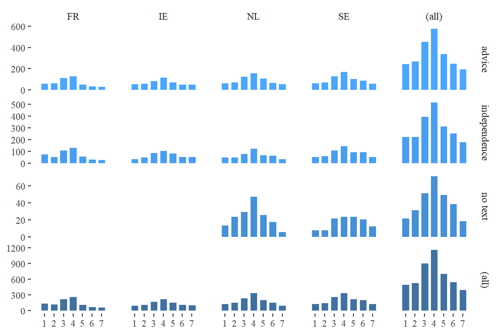

```r
pooled %>%
  ggplot(aes(x=credibility.item3.reversed, fill = experimental.group)) +
  geom_bar(width = 0.75,alpha=0.8)+
  scale_x_continuous(name="",limits = c(0,8),breaks = 1:7)+
  scale_fill_manual(values = c("dodgerblue1", "dodgerblue2","dodgerblue3", "dodgerblue4"))+
  facet_grid(experimental.group ~ country,  margins=TRUE, scale="free") +
  theme_tufte() +
  theme(legend.position = "none", axis.title = element_blank())
```

Item 4: I believe that the EMA’s opinion was formed after evaluating all the relevant data and evidence.

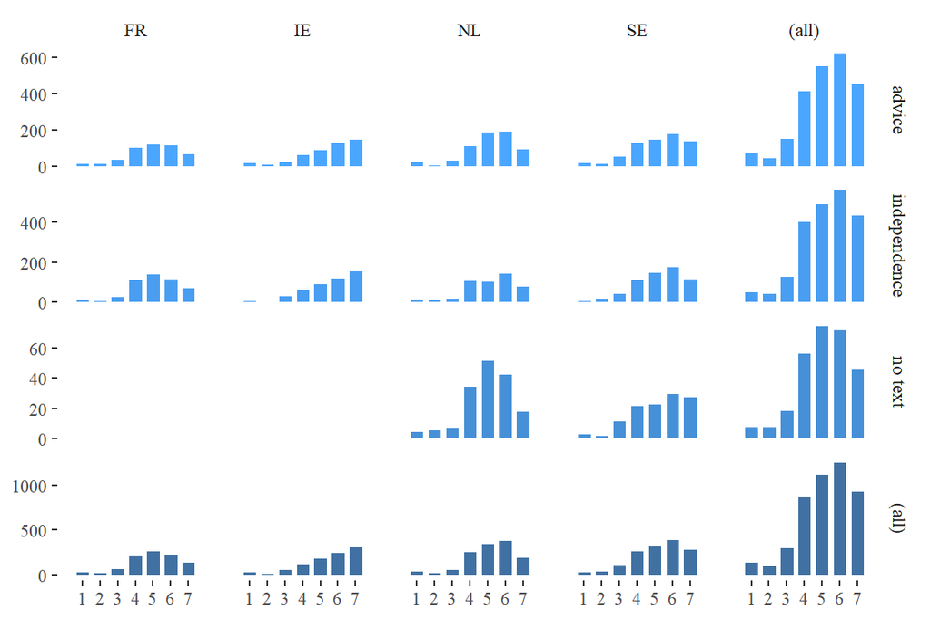

```r
pooled %>%
  ggplot(aes(x=credibility.item4, fill = experimental.group)) +
  geom_bar(width = 0.75,alpha=0.8)+
  scale_x_continuous(name="",limits = c(0,8),breaks = 1:7)+
  scale_fill_manual(values = c("dodgerblue1", "dodgerblue2","dodgerblue3", "dodgerblue4"))+
  facet_grid(experimental.group ~ country,  margins=TRUE, scale="free") +
  theme_tufte() +
  theme(legend.position = "none", axis.title = element_blank())
```

Item 5: I believe that the assessment of the evidence was based on adequate methods.

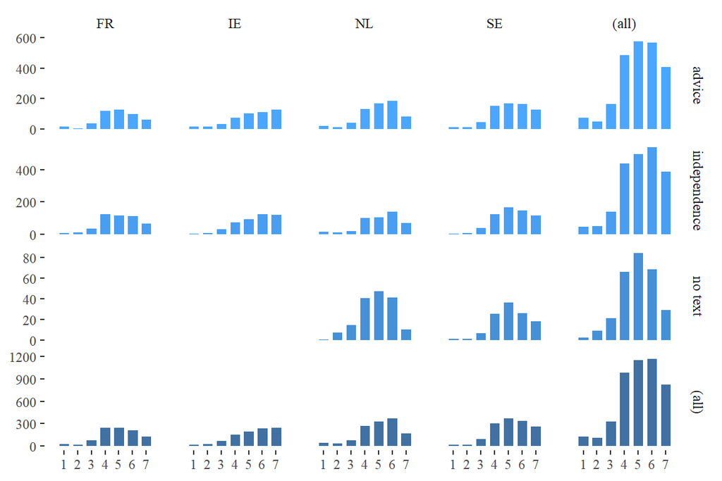

```r
pooled %>%
  ggplot(aes(x=credibility.item5, fill = experimental.group)) +
  geom_bar(width = 0.75,alpha=0.8)+
  scale_x_continuous(name="",limits = c(0,8),breaks = 1:7)+
  scale_fill_manual(values = c("dodgerblue1", "dodgerblue2","dodgerblue3", "dodgerblue4"))+
  facet_grid(experimental.group ~ country,  margins=TRUE, scale="free") +
  theme_tufte() +
  theme(legend.position = "none", axis.title = element_blank())
```

Item 6: Assuming that the scientific evidence does not change, I believe that EMA’s opinion about the Pfizer-BioNTech vaccine will not change the next time EMA is asked to re-examine it.

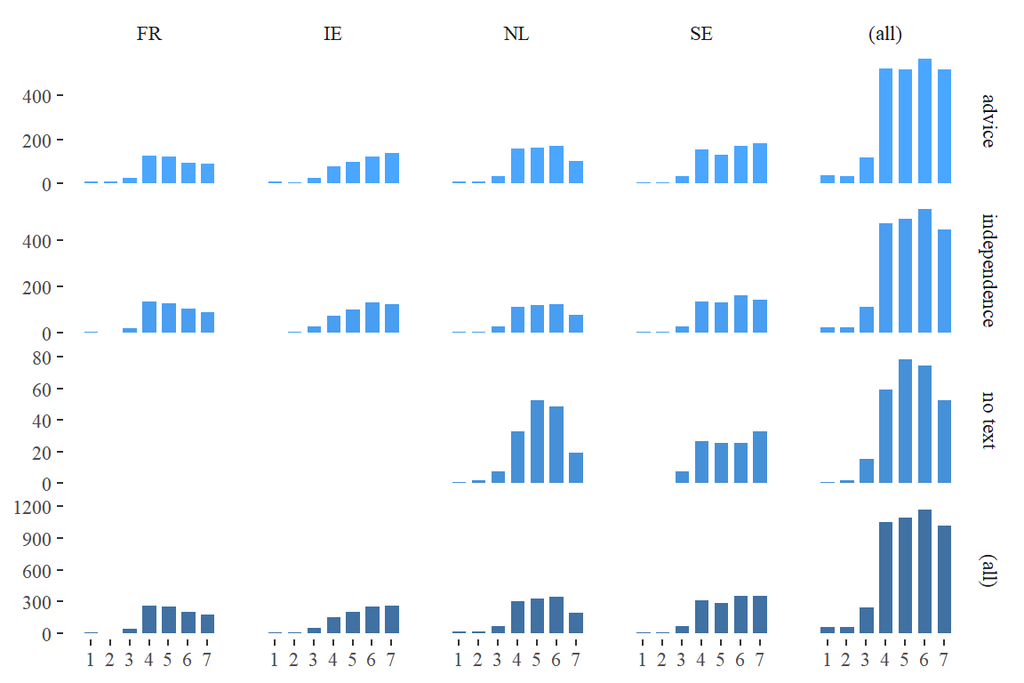

```r
pooled %>%
  ggplot(aes(x=credibility.item6, fill = experimental.group)) +
  geom_bar(width = 0.75,alpha=0.8)+
  scale_x_continuous(name="",limits = c(0,8),breaks = 1:7)+
  scale_fill_manual(values = c("dodgerblue1", "dodgerblue2","dodgerblue3", "dodgerblue4"))+
  facet_grid(experimental.group ~ country,  margins=TRUE, scale="free") +
  theme_tufte() +
  theme(legend.position = "none", axis.title = element_blank())
```

**Correlation matrix**

```r
pooled.credibility <- pooled %>%
  select(credibility.item1:credibility.item6, country) %>%
  mutate(item1 = credibility.item1,
         item2 = credibility.item2.reversed,
         item3 = credibility.item3.reversed,
         item4 = credibility.item4,
         item5 = credibility.item5,
         item6 = credibility.item6,
         .keep = "unused")

pooled.credibility %>% select(-country) %>%
  tab_corr(triangle="lower",
           remove.spaces=T,
           p.numeric = T,
           fade.ns = T,
           digits = 2,
           na.deletion="pairwise",
           title = "Correlation matrix: items of policy credibility scale",
           var.labels = str_c("Item ",1:6))
```

Correlation matrix: items of policy credibility scale

|  | Item 1 | Item 2 | Item 3 | Item 4 | Item 5 | Item 6 |
| --- | --- | --- | --- | --- | --- | --- |
| Item 1 |  |  |  |  |  |  |
| Item 2 | 0.42 (<.001) |  |  |  |  |  |
| Item 3 | 0.38 (<.001) | 0.74 (<.001) |  |  |  |  |
| Item 4 | 0.68 (<.001) | 0.44 (<.001) | 0.39 (<.001) |  |  |  |
| Item 5 | 0.67 (<.001) | 0.41 (<.001) | 0.39 (<.001) | 0.74 (<.001) |  |  |
| Item 6 | 0.42 (<.001) | 0.17 (<.001) | 0.17 (<.001) | 0.45 (<.001) | 0.48 (<.001) |  |
| Computed correlation used pearson-method with pairwise-deletion. |  |  |  |  |  |  |

# 3 Conformitory factor analysis

We conducted our confirmatory factor analysis using `R lavaan` package.

## 3.1 One-factor model - Single factor

**Model summary**

```r
fit.1factor <- cfa(factor.1.cfa,
           std.lv=TRUE,
           missing="fiml",
           data=pooled.credibility)

summary(fit.1factor,fit.measures=T,standardize=T)
```

```
## lavaan 0.6-7 ended normally after 17 iterations
##
##   Estimator                                         ML
##   Optimization method                           NLMINB
##   Number of free parameters                         18
##
##   Number of observations                          4749
##   Number of missing patterns                         1
##
## Model Test User Model:
##
##   Test statistic                              2789.517
##   Degrees of freedom                                 9
##   P-value (Chi-square)                           0.000
##
## Model Test Baseline Model:
##
##   Test statistic                             13778.583
##   Degrees of freedom                                15
##   P-value                                        0.000
##
## User Model versus Baseline Model:
##
##   Comparative Fit Index (CFI)                    0.798
##   Tucker-Lewis Index (TLI)                       0.663
##
## Loglikelihood and Information Criteria:
##
##   Loglikelihood user model (H0)             -47025.518
##   Loglikelihood unrestricted model (H1)     -45630.759
##
##   Akaike (AIC)                               94087.036
##   Bayesian (BIC)                             94203.418
##   Sample-size adjusted Bayesian (BIC)        94146.221
##
## Root Mean Square Error of Approximation:
##
##   RMSEA                                          0.255
##   90 Percent confidence interval - lower         0.247
##   90 Percent confidence interval - upper         0.263
```

[output cut: 26 more lines]

```
##    .item3             3.902    0.025  157.091    0.000    3.902    2.280
##    .item4             5.164    0.021  243.407    0.000    5.164    3.532
##    .item5             5.065    0.021  241.182    0.000    5.065    3.500
##    .item6             5.253    0.020  267.735    0.000    5.253    3.885
##     policy.crdblty    0.000                               0.000    0.000
##
## Variances:
##                    Estimate  Std.Err  z-value  P(>|z|)   Std.lv  Std.all
##    .item1             0.891    0.023   38.228    0.000    0.891    0.376
##    .item2             2.027    0.044   45.722    0.000    2.027    0.708
##    .item3             2.182    0.047   46.207    0.000    2.182    0.745
##    .item4             0.571    0.018   31.417    0.000    0.571    0.267
##    .item5             0.591    0.018   32.549    0.000    0.591    0.282
##    .item6             1.331    0.029   46.424    0.000    1.331    0.728
##     policy.crdblty    1.000                               1.000    1.000
```

**Visualization of the model**

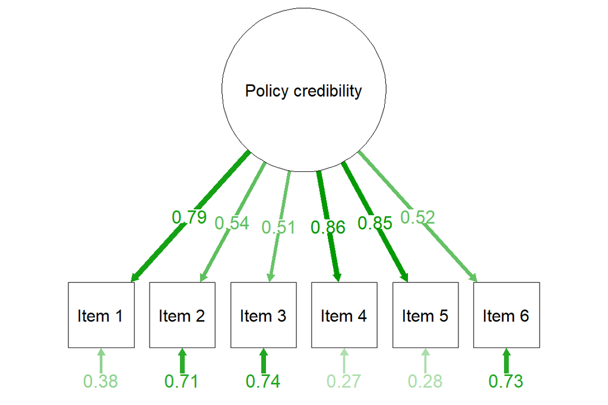

```r
semPaths(fit.1factor, "std",
         layout = "tree2",
         nCharNodes = 0,
         nCharEdges = 0,
         sizeMan = 12,
         sizeLat = 30,
         intercepts = FALSE,
         curvePivot = TRUE,
         edge.label.cex = 1.5,
         curveAdjacent = TRUE,
         style = "lisrel",
         label.scale = FALSE,
         nodeLabels = c(str_c("Item ",1:6), "Policy credibility"))
```

## 3.2 Three-factors model - base

**Model summary**

```r
fit.3factors.base <- cfa(factor.3.cfa.base,
           std.lv=TRUE,
           missing="fiml",
           data=pooled.credibility)

summary(fit.3factors.base, fit.measures=T,standardize=T)
```

```
## lavaan 0.6-7 ended normally after 21 iterations
##
##   Estimator                                         ML
##   Optimization method                           NLMINB
##   Number of free parameters                         20
##
##   Number of observations                          4749
##   Number of missing patterns                         1
##
## Model Test User Model:
##
##   Test statistic                              2418.862
##   Degrees of freedom                                 7
##   P-value (Chi-square)                           0.000
##
## Model Test Baseline Model:
##
##   Test statistic                             13778.583
##   Degrees of freedom                                15
##   P-value                                        0.000
##
## User Model versus Baseline Model:
##
##   Comparative Fit Index (CFI)                    0.825
##   Tucker-Lewis Index (TLI)                       0.624
##
## Loglikelihood and Information Criteria:
##
##   Loglikelihood user model (H0)             -46840.190
##   Loglikelihood unrestricted model (H1)     -45630.759
##
##   Akaike (AIC)                               93720.380
##   Bayesian (BIC)                             93849.694
##   Sample-size adjusted Bayesian (BIC)        93786.141
##
## Root Mean Square Error of Approximation:
##
##   RMSEA                                          0.269
##   90 Percent confidence interval - lower         0.260
##   90 Percent confidence interval - upper         0.278
```

[output cut: 40 more lines]

```
##     non.interfernc    0.000                               0.000    0.000
##     expertise         0.000                               0.000    0.000
##     stability         0.000                               0.000    0.000
##
## Variances:
##                    Estimate  Std.Err  z-value  P(>|z|)   Std.lv  Std.all
##    .item1             1.658    0.039   42.647    0.000    1.658    0.700
##    .item2             0.737    0.032   22.912    0.000    0.737    0.258
##    .item3             0.955    0.032   30.311    0.000    0.955    0.326
##    .item4             0.572    0.024   24.273    0.000    0.572    0.267
##    .item5             0.541    0.023   23.393    0.000    0.541    0.258
##    .item6             0.000                               0.000    0.000
##     non.interfernc    1.000                               1.000    1.000
##     expertise         1.000                               1.000    1.000
##     stability         1.000                               1.000    1.000
```

**Visualization of the model**

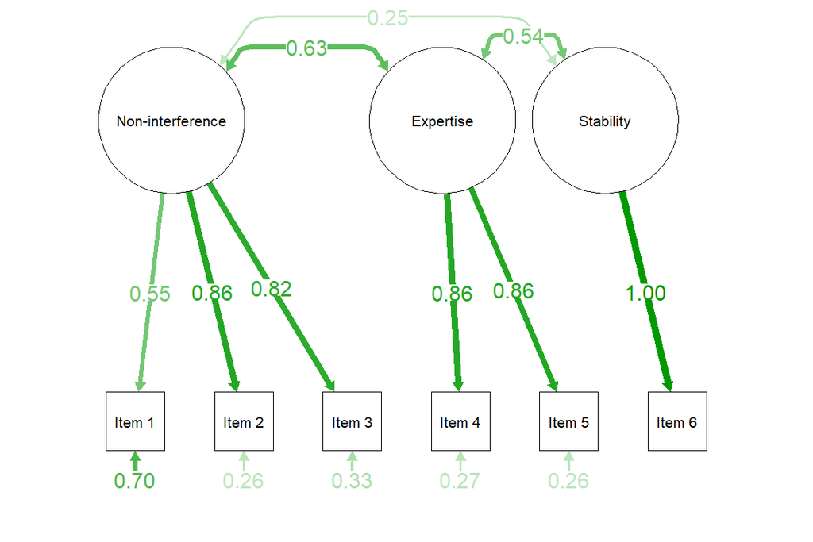

```r
semPaths(fit.3factors.base,  "std",
         layout = "tree2",
         nCharNodes = 0,
         nCharEdges = 0,
         sizeMan = 8,
         sizeLat = 20,
         intercepts = FALSE,
         curvePivot = TRUE,
         edge.label.cex = 1.3,
         curveAdjacent = TRUE,
         style = "lisrel",
         label.scale = FALSE,
         label.cex = 0.65,
         nodeLabels = c(str_c("Item ",1:6), "Non-interference", "Expertise", "Stability"))
```

**Modification indices**

```r
fit.improve.base <- modificationindices(fit.3factors.base, standardized =TRUE)

fit.improve.base %>%
  as_tibble() %>%
  slice_max(mi, n = 10) %>%
  arrange(-mi) %>%
  select( 'Left hand side' = lhs, Operator = op, 'Right hand side' = rhs, 'Modification index' = mi,  'Expected parameter change'= epc) %>%
  kable(digits = 3) %>%
    kable_styling(bootstrap_options = c("condensed",  "striped", "hover"),
                full_width = F,
                position = "left")
```

| Left hand side | Operator | Right hand side | Modification index | Expected parameter change |
| --- | --- | --- | --- | --- |
| expertise | =~ | item1 | 2106.841 | 1.381 |
| item2 | ~~ | item3 | 1983.845 | 3.109 |
| stability | =~ | item1 | 650.011 | 0.517 |
| expertise | =~ | item2 | 311.930 | -0.664 |
| item1 | ~~ | item3 | 288.160 | -0.511 |
| item1 | ~~ | item4 | 285.444 | 0.311 |
| item1 | ~~ | item5 | 272.862 | 0.300 |
| item1 | ~~ | item2 | 259.320 | -0.500 |
| expertise | =~ | item3 | 240.431 | -0.561 |
| stability | =~ | item2 | 83.800 | -0.179 |

It can be gleaned from this table that allowing item 2 and item 3 to correlate enhances the fit of the model. This makes sense as these variables are asked in a very similar way. The next model shows the result of this adjustment.

**Key parameters**

```r
parameterEstimates(fit.3factors.base, standardized=TRUE) %>%
  filter(op == "=~") %>%
  select('Latent Factor'=lhs, Indicator=rhs, B=est, SE=se, Z=z, 'p-value'=pvalue, Beta=std.all) %>%
  mutate(Indicator = c(str_c("Item ",1:6))) %>%
  kable(digits = 3) %>%
    kable_styling(bootstrap_options = c("condensed"),
                full_width = F,
                position = "left")%>%
  collapse_rows(columns = 1, valign = "top")
```

| Latent Factor | Indicator | B | SE | Z | p-value | Beta |
| --- | --- | --- | --- | --- | --- | --- |
| non.interference | Item 1 | 0.844 | 0.023 | 36.038 | 0 | 0.548 |
|  | Item 2 | 1.457 | 0.022 | 66.943 | 0 | 0.862 |
|  | Item 3 | 1.405 | 0.022 | 63.731 | 0 | 0.821 |
| expertise | Item 4 | 1.251 | 0.019 | 66.708 | 0 | 0.856 |
|  | Item 5 | 1.247 | 0.019 | 67.256 | 0 | 0.861 |
| stability | Item 6 | 1.352 | 0.014 | 97.458 | 0 | 1.000 |

## 3.3 Three-factors model - adjusted

**Model summary**

```r
fit.3factors.adjusted <- cfa(factor.3.cfa.adjusted,
           std.lv=TRUE,
           missing="fiml",
           data=pooled.credibility)

summary(fit.3factors.adjusted, fit.measures=T, standardize=T)
```

```
## lavaan 0.6-7 ended normally after 29 iterations
##
##   Estimator                                         ML
##   Optimization method                           NLMINB
##   Number of free parameters                         21
##
##   Number of observations                          4749
##   Number of missing patterns                         1
##
## Model Test User Model:
##
##   Test statistic                                92.303
##   Degrees of freedom                                 6
##   P-value (Chi-square)                           0.000
##
## Model Test Baseline Model:
##
##   Test statistic                             13778.583
##   Degrees of freedom                                15
##   P-value                                        0.000
##
## User Model versus Baseline Model:
##
##   Comparative Fit Index (CFI)                    0.994
##   Tucker-Lewis Index (TLI)                       0.984
##
## Loglikelihood and Information Criteria:
##
##   Loglikelihood user model (H0)             -45676.911
##   Loglikelihood unrestricted model (H1)     -45630.759
##
##   Akaike (AIC)                               91395.821
##   Bayesian (BIC)                             91531.601
##   Sample-size adjusted Bayesian (BIC)        91464.870
##
## Root Mean Square Error of Approximation:
##
##   RMSEA                                          0.055
##   90 Percent confidence interval - lower         0.045
##   90 Percent confidence interval - upper         0.065
```

[output cut: 42 more lines]

```
##     non.interfernc    0.000                               0.000    0.000
##     expertise         0.000                               0.000    0.000
##     stability         0.000                               0.000    0.000
##
## Variances:
##                    Estimate  Std.Err  z-value  P(>|z|)   Std.lv  Std.all
##    .item1             0.771    0.038   20.499    0.000    0.771    0.325
##    .item2             2.118    0.047   45.527    0.000    2.118    0.740
##    .item3             2.293    0.050   46.299    0.000    2.293    0.783
##    .item4             0.553    0.019   29.325    0.000    0.553    0.258
##    .item5             0.559    0.019   30.155    0.000    0.559    0.267
##    .item6             0.000                               0.000    0.000
##     non.interfernc    1.000                               1.000    1.000
##     expertise         1.000                               1.000    1.000
##     stability         1.000                               1.000    1.000
```

**Visualization of the model**

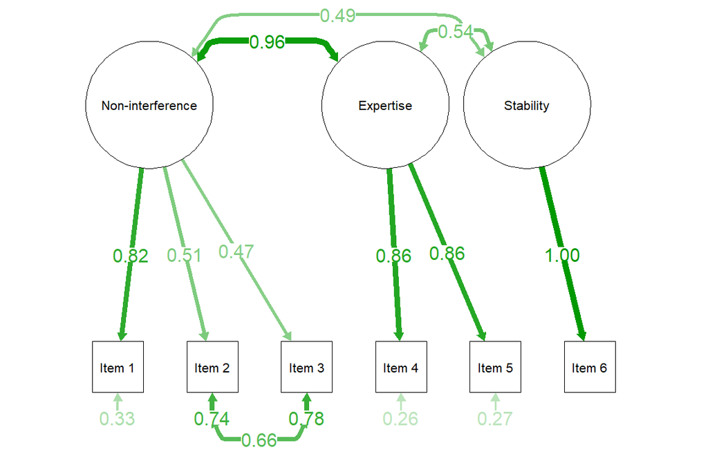

```r
semPaths(fit.3factors.adjusted,
         "std",
         layout = "tree2",
         nCharNodes = 0,
         nCharEdges = 0,
         sizeMan = 8,
         sizeLat = 20,
         intercepts = FALSE,
         curvePivot = TRUE,
         edge.label.cex = 1.3,
         curveAdjacent = TRUE,
         style = "lisrel",
         label.scale = FALSE,
         label.cex = 0.65,
         nodeLabels = c(str_c("Item ",1:6), "Non-interference", "Expertise", "Stability"))
```

**Modification indices**

```r
fit.improve.adjusted <- modificationindices(fit.3factors.adjusted)

fit.improve.adjusted %>%
  as_tibble() %>%
  slice_max(mi, n = 10) %>%
  arrange(-mi) %>%
  select( 'Left hand side' = lhs, Operator = op, 'Right hand side' = rhs, 'Modification index' = mi,  'Expected parameter change'= epc) %>%
  kable(digits = 3) %>%
    kable_styling(bootstrap_options = c("condensed",  "striped", "hover"),
                full_width = F,
                position = "left")
```

| Left hand side | Operator | Right hand side | Modification index | Expected parameter change |
| --- | --- | --- | --- | --- |
| item1 | ~~ | item6 | 60.216 | 0.294 |
| stability | =~ | item1 | 60.216 | 0.300 |
| expertise | =~ | item1 | 60.215 | 6.916 |
| stability | =~ | item2 | 28.912 | -0.103 |
| item2 | ~~ | item6 | 28.083 | -0.101 |
| item2 | ~~ | item4 | 17.064 | 0.064 |
| non.interference | =~ | item5 | 14.942 | -0.730 |
| non.interference | =~ | item4 | 14.942 | 0.742 |
| item4 | ~~ | item6 | 14.942 | -0.076 |
| item5 | ~~ | item6 | 14.942 | 0.075 |

Judging from this table, it seems that item 1 may be better assigned to the ‘expertise’ factor – instead of the ‘non-interference’ factor. Also, note the very high correlation between non-interference and expertise and the somewhat low loadings of item 2 and item 3. The next model shows what happens if item 1 is assigned to the ‘expertise’ factor.

**Key parameters**

```r
parameterEstimates(fit.3factors.adjusted, standardized=TRUE) %>%
  filter(op == "=~") %>%
  select('Latent Factor'=lhs, Indicator=rhs, B=est, SE=se, Z=z, 'p-value'=pvalue, Beta=std.all) %>%
  mutate(Indicator = c(str_c("Item ",1:6))) %>%
  kable(digits = 3) %>%
    kable_styling(bootstrap_options = c("condensed"),
                full_width = F,
                position = "left")%>%
  collapse_rows(columns = 1, valign = "top")
```

| Latent Factor | Indicator | B | SE | Z | p-value | Beta |
| --- | --- | --- | --- | --- | --- | --- |
| non.interference | Item 1 | 1.265 | 0.023 | 55.860 | 0 | 0.821 |
|  | Item 2 | 0.862 | 0.025 | 34.695 | 0 | 0.509 |
|  | Item 3 | 0.798 | 0.025 | 31.468 | 0 | 0.466 |
| expertise | Item 4 | 1.259 | 0.018 | 70.497 | 0 | 0.861 |
|  | Item 5 | 1.239 | 0.018 | 69.919 | 0 | 0.856 |
| stability | Item 6 | 1.352 | 0.014 | 97.458 | 0 | 1.000 |

## 3.4 Three-factors model - alternative

**Model summary**

```r
fit.3factors.alternative <- cfa(factor.3.cfa.alternative,
           std.lv=TRUE,
           missing="fiml",
           data=pooled.credibility)

summary(fit.3factors.alternative, standardize=T, fit.measures=T)
```

```
## lavaan 0.6-7 ended normally after 21 iterations
##
##   Estimator                                         ML
##   Optimization method                           NLMINB
##   Number of free parameters                         20
##
##   Number of observations                          4749
##   Number of missing patterns                         1
##
## Model Test User Model:
##
##   Test statistic                                43.442
##   Degrees of freedom                                 7
##   P-value (Chi-square)                           0.000
##
## Model Test Baseline Model:
##
##   Test statistic                             13778.583
##   Degrees of freedom                                15
##   P-value                                        0.000
##
## User Model versus Baseline Model:
##
##   Comparative Fit Index (CFI)                    0.997
##   Tucker-Lewis Index (TLI)                       0.994
##
## Loglikelihood and Information Criteria:
##
##   Loglikelihood user model (H0)             -45652.480
##   Loglikelihood unrestricted model (H1)     -45630.759
##
##   Akaike (AIC)                               91344.960
##   Bayesian (BIC)                             91474.274
##   Sample-size adjusted Bayesian (BIC)        91410.721
##
## Root Mean Square Error of Approximation:
##
##   RMSEA                                          0.033
##   90 Percent confidence interval - lower         0.024
##   90 Percent confidence interval - upper         0.043
```

[output cut: 40 more lines]

```
##     non.interfernc    0.000                               0.000    0.000
##     expertise         0.000                               0.000    0.000
##     stability         0.000                               0.000    0.000
##
## Variances:
##                    Estimate  Std.Err  z-value  P(>|z|)   Std.lv  Std.all
##    .item2             0.537    0.048   11.102    0.000    0.537    0.188
##    .item3             0.955    0.045   21.418    0.000    0.955    0.326
##    .item1             0.892    0.023   38.115    0.000    0.892    0.376
##    .item4             0.556    0.018   30.340    0.000    0.556    0.260
##    .item5             0.568    0.018   31.218    0.000    0.568    0.271
##    .item6             0.000                               0.000    0.000
##     non.interfernc    1.000                               1.000    1.000
##     expertise         1.000                               1.000    1.000
##     stability         1.000                               1.000    1.000
```

**Visualization of the model**

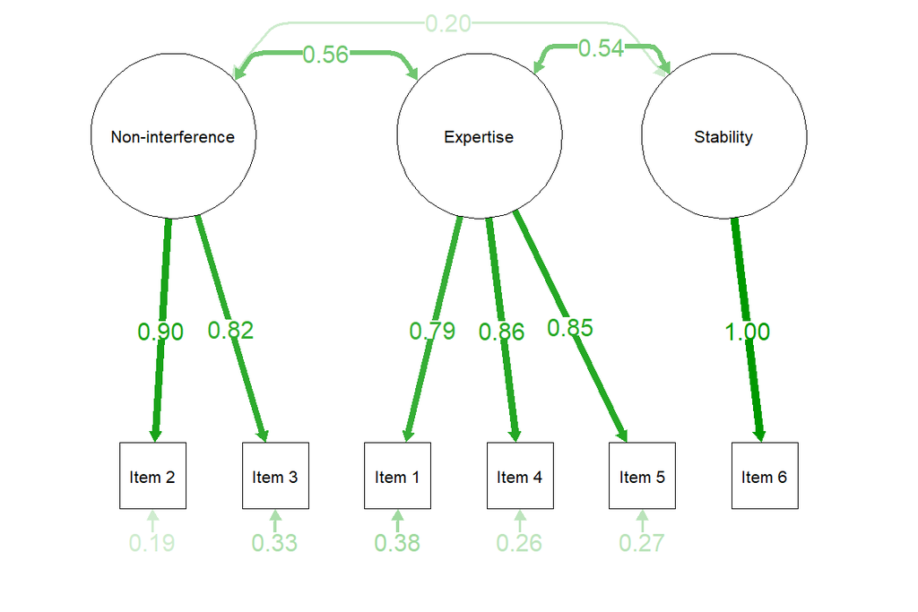

```r
semPaths(fit.3factors.alternative,
         "std",
         layout = "tree2",
         nCharNodes = 0,
         nCharEdges = 0,
         sizeMan = 8,
         sizeLat = 20,
         intercepts = FALSE,
         curvePivot = TRUE,
         edge.label.cex = 1.3,
         curveAdjacent = TRUE,
         style = "lisrel",
         label.scale = FALSE,
         label.cex = 0.65,
         nodeLabels = c("Item 2", "Item 3", "Item 1", "Item 4", "Item 5", "Item 6", "Non-interference", "Expertise", "Stability"))
```

**Modification indices**

```r
fit.improve.alternative <- modificationindices(fit.3factors.alternative)

fit.improve.alternative %>%
  as_tibble() %>%
  slice_max(mi, n = 10) %>%
  arrange(-mi) %>%
  select( 'Left hand side' = lhs, Operator = op, 'Right hand side' = rhs, 'Modification index' = mi,  'Expected parameter change'= epc) %>%
  kable(digits = 3) %>%
    kable_styling(bootstrap_options = c("condensed",  "striped", "hover"),
                full_width = F,
                position = "left")
```

| Left hand side | Operator | Right hand side | Modification index | Expected parameter change |
| --- | --- | --- | --- | --- |
| item2 | ~~ | item5 | 19.609 | -0.068 |
| stability | =~ | item5 | 14.537 | 0.068 |
| non.interference | =~ | item5 | 12.639 | -0.070 |
| item5 | ~~ | item6 | 11.968 | 0.060 |
| non.interference | =~ | item1 | 11.881 | 0.075 |
| item4 | ~~ | item6 | 10.390 | -0.056 |
| stability | =~ | item4 | 9.993 | -0.057 |
| item2 | ~~ | item1 | 9.041 | 0.052 |
| item3 | ~~ | item4 | 6.346 | -0.040 |
| item1 | ~~ | item5 | 5.921 | -0.052 |

No (theoretically sensible) improvements are possible.

**Key parameters**

```r
parameterEstimates(fit.3factors.alternative, standardized=TRUE) %>%
  filter(op == "=~")  %>%
 select('Latent Factor'=lhs, Indicator=rhs, B=est, SE=se, Z=z, 'p-value'=pvalue, Beta=std.all) %>%
  mutate(Indicator = c("Item 2", "Item 3", "Item 1", "Item 4", "Item 5", "Item 6")) %>%
  kable(digits = 3)%>%
    kable_styling(bootstrap_options = c("condensed"),
                full_width = F,
                position = "left") %>%
  collapse_rows(columns = 1, valign = "top")
```

| Latent Factor | Indicator | B | SE | Z | p-value | Beta |
| --- | --- | --- | --- | --- | --- | --- |
| non.interference | Item 2 | 1.524 | 0.024 | 62.413 | 0 | 0.901 |
|  | Item 3 | 1.405 | 0.025 | 56.811 | 0 | 0.821 |
| expertise | Item 1 | 1.216 | 0.019 | 62.410 | 0 | 0.790 |
|  | Item 4 | 1.257 | 0.018 | 70.720 | 0 | 0.860 |
|  | Item 5 | 1.236 | 0.018 | 69.922 | 0 | 0.854 |
| stability | Item 6 | 1.352 | 0.014 | 97.458 | 0 | 1.000 |

## 3.5 Model comparison

**1 factor vs. 3 factors (base)**

```r
lavTestLRT(fit.3factors.base, fit.1factor)
```

```
## Chi-Squared Difference Test
##
##                   Df   AIC   BIC  Chisq Chisq diff Df diff Pr(>Chisq)
## fit.3factors.base  7 93720 93850 2418.9
## fit.1factor        9 94087 94203 2789.5     370.66       2  < 2.2e-16 ***
## ---
## Signif. codes:  0 '***' 0.001 '**' 0.01 '*' 0.05 '.' 0.1 ' ' 1
```

**3 factors (base) vs. 3 factors (adjusted)**

```r
lavTestLRT(fit.3factors.base, fit.3factors.adjusted)
```

```
## Chi-Squared Difference Test
##
##                       Df   AIC   BIC    Chisq Chisq diff Df diff Pr(>Chisq)
## fit.3factors.adjusted  6 91396 91532   92.303
## fit.3factors.base      7 93720 93850 2418.862     2326.6       1  < 2.2e-16 ***
## ---
## Signif. codes:  0 '***' 0.001 '**' 0.01 '*' 0.05 '.' 0.1 ' ' 1
```

**1 factor vs. 3 factors (alternative)**

```r
lavTestLRT(fit.1factor, fit.3factors.alternative)
```

```
## Chi-Squared Difference Test
##
##                          Df   AIC   BIC    Chisq Chisq diff Df diff Pr(>Chisq)
## fit.3factors.alternative  7 91345 91474   43.442
## fit.1factor               9 94087 94203 2789.517     2746.1       2  < 2.2e-16
##
## fit.3factors.alternative
## fit.1factor              ***
## ---
## Signif. codes:  0 '***' 0.001 '**' 0.01 '*' 0.05 '.' 0.1 ' ' 1
```

## 3.6 Comparing models: A nice table

```r
cfa.compare <- cbind(
m1 = inspect(fit.1factor, 'fit.measures'),
m2 =inspect(fit.3factors.base, 'fit.measures'),
m3= inspect(fit.3factors.adjusted, 'fit.measures'),
m4 =inspect(fit.3factors.alternative, 'fit.measures'))

cfa.compare  %>%
   t() %>%
   as_tibble() %>%
   round(3) %>%
   unite("rmsea.ci", rmsea.ci.lower:rmsea.ci.upper, remove = FALSE, sep = " - ")  %>%
   select(Parameters = npar,
          "Chi-squared" = chisq,
          "Degrees of freedom" = df,
          "p-value" = pvalue,
          CFI = cfi,
          TLI = tli,
          AIC = aic,
          BIC = bic,
          RMSEA = rmsea,
          "RMSEA 95% CI" = rmsea.ci,
          "RMSEA p-value" = rmsea.pvalue) %>%
   mutate(Model = c("Single factor",
                     "Baseline",
                     "Adjusted",
                     "Alternative")) %>% relocate(Model) %>%
  kable(booktabs = TRUE) %>% pack_rows(
  index = c("One factor" = 1, "Three Factors" = 3)) %>%
    kable_styling(bootstrap_options = c("condensed",  "striped", "hover"),
                full_width = F,
                position = "left")
```

| Model | Parameters | Chi-squared | Degrees of freedom | p-value | CFI | TLI | AIC | BIC | RMSEA | RMSEA 95% CI | RMSEA p-value |
| --- | --- | --- | --- | --- | --- | --- | --- | --- | --- | --- | --- |
| **One factor** |  |  |  |  |  |  |  |  |  |  |  |
| Single factor | 18 | 2789.517 | 9 | 0 | 0.798 | 0.663 | 94087.04 | 94203.42 | 0.255 | 0.247 - 0.263 | 0.000 |
| **Three Factors** |  |  |  |  |  |  |  |  |  |  |  |
| Baseline | 20 | 2418.862 | 7 | 0 | 0.825 | 0.624 | 93720.38 | 93849.69 | 0.269 | 0.26 - 0.278 | 0.000 |
| Adjusted | 21 | 92.303 | 6 | 0 | 0.994 | 0.984 | 91395.82 | 91531.60 | 0.055 | 0.045 - 0.065 | 0.187 |
| Alternative | 20 | 43.442 | 7 | 0 | 0.997 | 0.994 | 91344.96 | 91474.27 | 0.033 | 0.024 - 0.043 | 0.998 |

## 3.7 Model per country

```r
fit.final.country <- cfa(factor.3.cfa.adjusted,
           data=pooled.credibility,
          std.lv=TRUE,
           missing="fiml",
          group = "country")

summary(fit.final.country, standardize=T, fit.measures=T)
```

```
## lavaan 0.6-7 ended normally after 91 iterations
##
##   Estimator                                         ML
##   Optimization method                           NLMINB
##   Number of free parameters                         84
##
##   Number of observations per group:
##     IE                                             982
##     FR                                             990
##     NL                                            1326
##     SE                                            1451
##   Number of missing patterns per group:
##     IE                                               1
##     FR                                               1
##     NL                                               1
##     SE                                               1
##
## Model Test User Model:
##
##   Test statistic                               115.081
##   Degrees of freedom                                24
##   P-value (Chi-square)                           0.000
##   Test statistic for each group:
##     IE                                          16.317
##     FR                                          26.055
##     NL                                          50.352
##     SE                                          22.357
##
## Model Test Baseline Model:
##
##   Test statistic                             13848.572
##   Degrees of freedom                                60
##   P-value                                        0.000
##
## User Model versus Baseline Model:
##
##   Comparative Fit Index (CFI)                    0.993
##   Tucker-Lewis Index (TLI)                       0.983
##
## Loglikelihood and Information Criteria:
```

[output cut: 205 more lines]

```
##     non.interfernc    0.000                               0.000    0.000
##     expertise         0.000                               0.000    0.000
##     stability         0.000                               0.000    0.000
##
## Variances:
##                    Estimate  Std.Err  z-value  P(>|z|)   Std.lv  Std.all
##    .item1             0.513    0.064    7.968    0.000    0.513    0.215
##    .item2             2.026    0.080   25.194    0.000    2.026    0.715
##    .item3             2.150    0.085   25.280    0.000    2.150    0.732
##    .item4             0.494    0.034   14.725    0.000    0.494    0.233
##    .item5             0.603    0.032   19.020    0.000    0.603    0.317
##    .item6             0.000                               0.000    0.000
##     non.interfernc    1.000                               1.000    1.000
##     expertise         1.000                               1.000    1.000
##     stability         1.000                               1.000    1.000
```

**Visualization of the model**

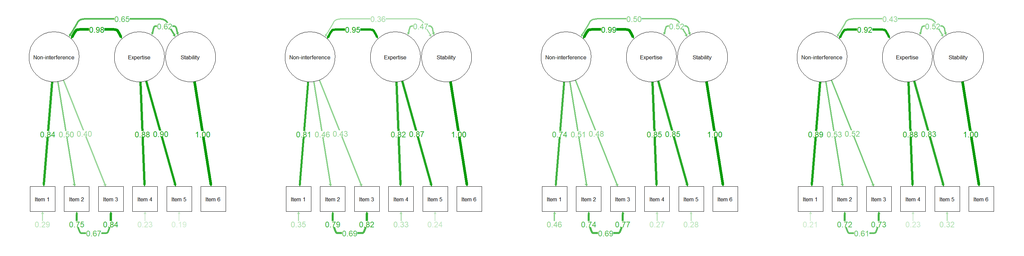

```r
semPaths(fit.final.country,
         "std",
         layout = "tree2",
         nCharNodes = 0,
         nCharEdges = 0,
         intercepts = FALSE,
         curvePivot = TRUE,
         sizeMan = 14,
         sizeLat = 28,
         edge.label.cex = 2,
        label.cex = 0.8,
         style = "lisrel",
         label.scale = FALSE,
         nodeLabels = c(str_c("Item ",1:6), "Non-interference", "Expertise", "Stability"),
         panelGroups = TRUE,
         title = FALSE)
```

From left to right: Ireland, France, Netherlands, Sweden.

**Key parameters**

```r
parameterEstimates(fit.final.country, standardized=TRUE) %>%
  filter(op == "=~") %>%
  mutate(Country = case_when(
    group == 1 ~ "Ireland",
    group == 2 ~ "France",
    group == 3 ~ "Netherlands",
    group == 4 ~ "Sweden"
  ))  %>%
 select('Latent Factor'=lhs, Indicator=rhs, B=est, SE=se, Z=z, 'p-value'=pvalue, Beta=std.all, Country)  %>%
     relocate(Country) %>%
  kable(digits = 3) %>% pack_rows(
  index = c("Ireland" = 6, "France" = 6, "Netherlands" = 6, "Sweden" =6)) %>%
    kable_styling(bootstrap_options = c("condensed","striped", "hover"),
                full_width = F,
                position = "left")
```

| Country | Latent Factor | Indicator | B | SE | Z | p-value | Beta |
| --- | --- | --- | --- | --- | --- | --- | --- |
| **Ireland** |  |  |  |  |  |  |  |
| Ireland | non.interference | item1 | 1.282 | 0.047 | 27.035 | 0 | 0.843 |
| Ireland | non.interference | item2 | 0.881 | 0.056 | 15.660 | 0 | 0.496 |
| Ireland | non.interference | item3 | 0.698 | 0.057 | 12.308 | 0 | 0.398 |
| Ireland | expertise | item4 | 1.334 | 0.040 | 33.673 | 0 | 0.876 |
| Ireland | expertise | item5 | 1.384 | 0.039 | 35.210 | 0 | 0.902 |
| Ireland | stability | item6 | 1.390 | 0.031 | 44.317 | 0 | 1.000 |
| **France** |  |  |  |  |  |  |  |
| France | non.interference | item1 | 1.218 | 0.052 | 23.411 | 0 | 0.808 |
| France | non.interference | item2 | 0.756 | 0.054 | 14.064 | 0 | 0.462 |
| France | non.interference | item3 | 0.706 | 0.055 | 12.898 | 0 | 0.428 |
| France | expertise | item4 | 1.168 | 0.040 | 29.551 | 0 | 0.817 |
| France | expertise | item5 | 1.243 | 0.039 | 32.145 | 0 | 0.869 |
| France | stability | item6 | 1.333 | 0.030 | 44.497 | 0 | 1.000 |
| **Netherlands** |  |  |  |  |  |  |  |
| Netherlands | non.interference | item1 | 1.117 | 0.044 | 25.267 | 0 | 0.738 |
| Netherlands | non.interference | item2 | 0.854 | 0.048 | 17.943 | 0 | 0.514 |
| Netherlands | non.interference | item3 | 0.812 | 0.048 | 16.941 | 0 | 0.481 |
| Netherlands | expertise | item4 | 1.203 | 0.033 | 36.100 | 0 | 0.852 |
| Netherlands | expertise | item5 | 1.222 | 0.034 | 35.764 | 0 | 0.846 |
| Netherlands | stability | item6 | 1.314 | 0.026 | 51.498 | 0 | 1.000 |
| **Sweden** |  |  |  |  |  |  |  |
| Sweden | non.interference | item1 | 1.370 | 0.039 | 35.317 | 0 | 0.886 |
| Sweden | non.interference | item2 | 0.898 | 0.044 | 20.478 | 0 | 0.534 |
| Sweden | non.interference | item3 | 0.888 | 0.045 | 19.727 | 0 | 0.518 |
| Sweden | expertise | item4 | 1.275 | 0.032 | 39.888 | 0 | 0.876 |
| Sweden | expertise | item5 | 1.140 | 0.031 | 36.786 | 0 | 0.826 |
| Sweden | stability | item6 | 1.349 | 0.025 | 53.870 | 0 | 1.000 |

**Invariance**

```r
invariance <- measEq.syntax(configural.model = factor.3.cfa.adjusted,
                      data = pooled.credibility,
                      ordered = c("item1", "item2", "item3", "item4", "item5", "item6"),
                      parameterization = "theta",
                      ID.fac = "std.lv",
                      ID.cat = "Wu.Estabrook.2016",
                      group = "country",
                      group.equal = "configural")

invariance.model <- as.character(invariance)

invaraince.fit <- cfa(invariance.model,
                    data = pooled.credibility,
                    group = "country",
                     ordered = c("item1",
                                 "item2",
                                 "item3",
                                 "item4",
                                 "item5",
                                 "item6"))

summary(invaraince.fit)
```

```
## lavaan 0.6-7 ended normally after 37 iterations
##
##   Estimator                                       DWLS
##   Optimization method                           NLMINB
##   Number of free parameters                        184
##
##   Number of observations per group:
##     IE                                             982
##     FR                                             990
##     NL                                            1326
##     SE                                            1451
##
## Model Test User Model:
##                                               Standard      Robust
##   Test Statistic                               134.523     134.523
##   Degrees of freedom                                20          20
##   P-value (Chi-square)                           0.000       0.000
##   Scaling correction factor                                     NA
##   Shift parameter for each group:
##       IE
##       FR                                                    Robust
##       NL                                                   134.523
##       SE                                                        20
##                                                              0.000
##   Test statistic for each group:
##     IE                                          21.083      21.083
##     FR                                          40.787      40.787
##     NL                                          51.692      51.692
##     SE                                          20.961      20.961
##
## Parameter Estimates:
##
##   Standard errors                           Robust.sem
##   Information                                 Expected
##   Information saturated (h1) model        Unstructured
##
##
## Group 1 [IE]:
##
## Latent Variables:
```

[output cut: 368 more lines]

```
##    .item4   (t.4_)    0.186
##    .item5   (t.5_)    0.272
##    .item6   (t.6_)   -0.230
##     nn.ntrf (p.1_)    1.000
##     experts (p.2_)    1.000
##     stablty (p.3_)    1.000
##
## Scales y*:
##                    Estimate  Std.Err  z-value  P(>|z|)
##     item1             1.000
##     item2             1.000
##     item3             1.000
##     item4             1.000
##     item5             1.000
##     item6             1.000
```

```r
# 'MeasE1.syntax' is the successor of the now deprecated function 'measurementInvariance'. It can be used to analyze (in)variance between groups: https://lavaan.ugent.be/tutorial/groups.html.
# However, the current code gives a warning and the output seems incorrect.
# See for instructions: https://towardsdatascience.com/measurement-invariance-definition-and-example-in-r-15b4efcab351
```

This code gives a warning. Further examination is needed.

# 4 Trust in EU institutions

## 4.1 Distribution of items

Trust in the European Parliament

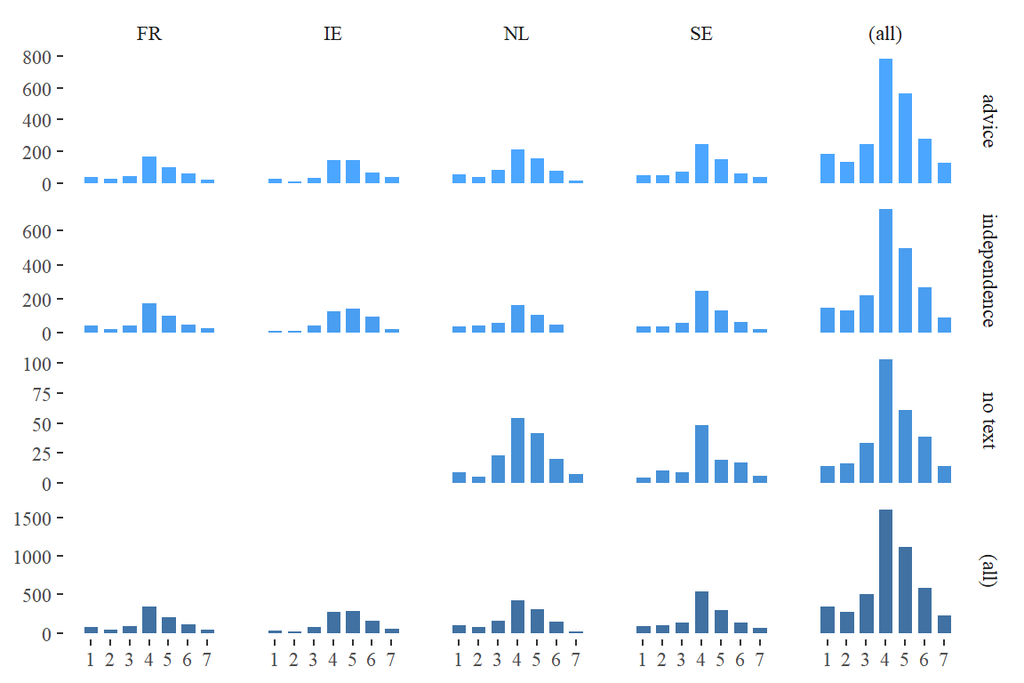

```r
pooled %>%
  ggplot(aes(x=trust.EP, fill = experimental.group)) +
  geom_bar(width = 0.75,alpha=0.8)+
  scale_x_continuous(name="",limits = c(0,8),breaks = 1:7)+
  scale_fill_manual(values = c("dodgerblue1", "dodgerblue2","dodgerblue3", "dodgerblue4"))+
  facet_grid(experimental.group ~ country,  margins=TRUE, scale="free") +
  theme_tufte() +
  theme(legend.position = "none", axis.title = element_blank())
```

Trust in the European Commission

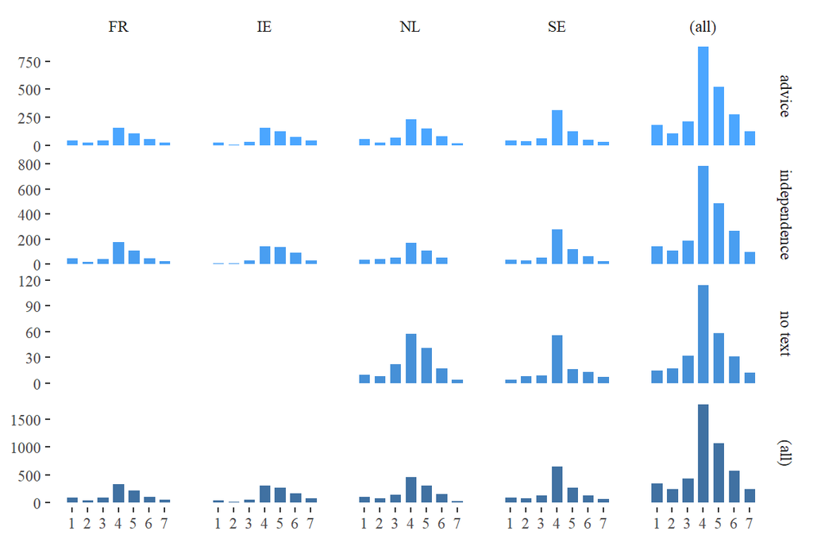

```r
pooled %>%
  ggplot(aes(x=trust.EC, fill = experimental.group)) +
  geom_bar(width = 0.75,alpha=0.8)+
  scale_x_continuous(name="",limits = c(0,8),breaks = 1:7)+
  scale_fill_manual(values = c("dodgerblue1", "dodgerblue2","dodgerblue3", "dodgerblue4"))+
  facet_grid(experimental.group ~ country,  margins=TRUE, scale="free") +
  theme_tufte() +
  theme(legend.position = "none", axis.title = element_blank())
```

Trust in the Council of the EU

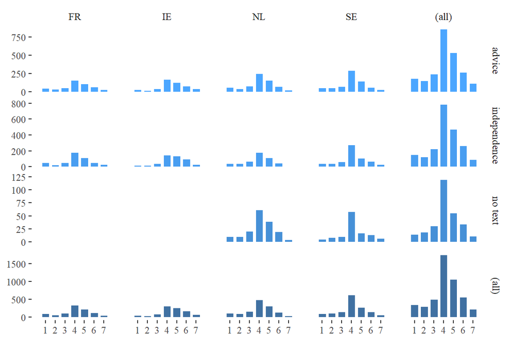

```r
pooled %>%
  ggplot(aes(x=trust.council, fill = experimental.group)) +
  geom_bar(width = 0.75,alpha=0.8)+
  scale_x_continuous(name="",limits = c(0,8),breaks = 1:7)+
  scale_fill_manual(values = c("dodgerblue1", "dodgerblue2","dodgerblue3", "dodgerblue4"))+
  facet_grid(experimental.group ~ country,  margins=TRUE, scale="free") +
  theme_tufte() +
  theme(legend.position = "none", axis.title = element_blank())
```

## 4.2 Correlation matrix

```r
pooled.trust <- pooled %>%
  select(trust.EP, trust.EC, trust.council)

pooled.trust %>%
  tab_corr(triangle="lower",
           remove.spaces=T,
           p.numeric = T,
           fade.ns = T,
           digits = 2,
           na.deletion="pairwise",
           title = "Correlation matrix: Trust in EU institutions",
           var.labels = c("European Parliament", "European Commission", "Council of the EU"))
```

Correlation matrix: Trust in EU institutions

|  | European Parliament | European Commission | Council of the EU |
| --- | --- | --- | --- |
| European Parliament |  |  |  |
| European Commission | 0.90 (<.001) |  |  |
| Council of the EU | 0.91 (<.001) | 0.89 (<.001) |  |
| Computed correlation used pearson-method with pairwise-deletion. |  |  |  |

## 4.3 Reliability indices

```r
alpha.trust <- alpha(pooled.trust)[[1]]
alpha.trust %>% select(-c(average_r, median_r, `S/N`, ase)) %>% kable(col.names = c("Raw alpha",
                       "Standarized alpha",
                      "Guttman's Lambda 6",
                      "Mean of trust in EU institutions",
                      "SD of trust in EU institutions"),
                      digits = 3) %>%
    kable_styling(bootstrap_options = c("condensed", "striped", "hover"),
                full_width = F,
                position = "left")
```

|  | Raw alpha | Standarized alpha | Guttman’s Lambda 6 | Mean of trust in EU institutions | SD of trust in EU institutions |
| --- | --- | --- | --- | --- | --- |
|  | 0.964 | 0.964 | 0.947 | 4.184 | 1.412 |

# 5 Summary statistics

Variable

n

% missing

Mean

SD

Median

Range

Skew

1. Credibility (expertise)

4749

0.000

5.114

1.356

5.000

6 (1-7)

-0.683

2. Credibility (stability)

4749

0.000

5.253

1.352

5.000

6 (1-7)

-0.540

3. Credibility (non-interference)

4749

0.000

4.208

1.360

4.000

6 (1-7)

0.005

4. Credibility index

4749

0.000

4.684

1.141

4.667

6 (1-7)

-0.130

5. Perceived political independence

4749

0.000

3.290

1.473

3.000

6 (1-7)

0.406

6. Vaccination intention

4749

0.000

2.981

1.053

3.000

3 (1-4)

-0.680

7. Trust in EU institutions

4749

0.000

4.184

1.412

4.000

6 (1-7)

-0.437

8. Trust in scientists

4749

0.000

5.181

1.354

5.000

6 (1-7)

-0.799

9. Trust in politicians

4749

0.000

3.628

1.629

4.000

6 (1-7)

-0.112

10. Trust in the media

1760

62.940

3.481

1.553

4.000

6 (1-7)

0.006

11. Political ideology (left-right)

4749

0.000

4.067

1.464

4.000

6 (1-7)

-0.046

12. Support for EU integration

4749

0.000

3.941

1.607

4.000

6 (1-7)

-0.134

13. Interpersonal trust

4749

0.000

3.602

1.670

4.000

6 (1-7)

-0.034

14. Familiarity with EMA

4749

0.000

3.535

1.786

4.000

6 (1-7)

0.161

15. Familiarity with EMA’s opinion

4749

0.000

3.897

1.872

4.000

6 (1-7)

-0.068

16. Crebility of EMA (pre-manipulation)

4749

0.000

4.638

1.480

5.000

6 (1-7)

-0.532

17. Crebility of EMA (post-manipulation)

2129

55.170

5.023

1.444

5.000

6 (1-7)

-0.598

18. Trust in public health authorities

4748

0.021

4.589

1.712

5.000

6 (1-7)

-0.577

19. Consequences of coronacrisis for health

4748

0.021

5.289

1.689

6.000

6 (1-7)

-0.918

20. Consequences of coronacrisis for income

4748

0.021

4.330

1.949

4.000

6 (1-7)

-0.219

21. Importance of EMA’s opinion

4749

0.000

0.741

0.438

1.000

1 (0-1)

-1.103

22. Importance of other regulators’ opinion (e.g., FDA)

4749

0.000

0.608

0.488

1.000

1 (0-1)

-0.442

23. Importance of NRA’s opinion

4749

0.000

0.751

0.433

1.000

1 (0-1)

-1.161

24. Believe in private markets

4749

0.000

4.256

1.622

4.000

6 (1-7)

-0.268

25. Knowledge of coronacrisis

4748

0.021

0.543

0.498

1.000

1 (0-1)

-0.171

26. Benefits of vaccines

4749

0.000

5.295

1.597

6.000

6 (1-7)

-0.903

27. Independence condition

4749

0.000

0.446

0.497

0.000

1 (0-1)

0.216

28. Advice condition

4749

0.000

0.493

0.500

0.000

1 (0-1)

0.027

29. No text condtion

4749

0.000

0.060

0.238

0.000

1 (0-1)

3.698

30. Gender (Female = 1)

4740

0.190

0.520

0.500

1.000

1 (0-1)

-0.079

31. Works in healthcare

4749

0.000

0.088

0.283

0.000

1 (0-1)

2.914

32. Age

4749

0.000

47.288

16.909

47.000

82 (18-100)

0.039

```r
pooled %>%
  select(expertise,
         stability,
         noninterference,
         credibility.index,
         perceived.independence.reversed,
         intent.vaccine,

         trust.EU.institutions,
         trust.scientist,
         trust.politicians,
         trust.media,
         political.ideology,
         EU.integration,
         interpersonal.trust,
         familiarity.EMA,
         familiarity.advice,
         credibility.EMA.pre,
         credibility.EMA.post,
         trust.health.authorities,
         consequences.health,
         consequences.economic,
         importance.EMA,
         importance.FDA ,
         importance.NRA,
         private.providers,
         knowledge,
         benefits.vaccines,
         independence,
         advice,

          female,
          healthcare,
         age) %>%
  tab_corr(triangle="lower",
           remove.spaces=T,
           p.numeric = T,
           show.p = T,
           fade.ns = F,
           digits = 2,
           na.deletion="pairwise",
           var.labels = str_c("Variable ", c(1:28,30:32)))
```

|  | Variable 1 | Variable 2 | Variable 3 | Variable 4 | Variable 5 | Variable 6 | Variable 7 | Variable 8 | Variable 9 | Variable 10 | Variable 11 | Variable 12 | Variable 13 | Variable 14 | Variable 15 | Variable 16 | Variable 17 | Variable 18 | Variable 19 | Variable 20 | Variable 21 | Variable 22 | Variable 23 | Variable 24 | Variable 25 | Variable 26 | Variable 27 | Variable 28 | Variable 30 | … |
| --- | --- | --- | --- | --- | --- | --- | --- | --- | --- | --- | --- | --- | --- | --- | --- | --- | --- | --- | --- | --- | --- | --- | --- | --- | --- | --- | --- | --- | --- | --- |
| Variable 1 |  |  |  |  |  |  |  |  |  |  |  |  |  |  |  |  |  |  |  |  |  |  |  |  |  |  |  |  |  | … |
| Variable 2 | 0.50 (<.001) |  |  |  |  |  |  |  |  |  |  |  |  |  |  |  |  |  |  |  |  |  |  |  |  |  |  |  |  | … |
| Variable 3 | 0.64 (<.001) | 0.30 (<.001) |  |  |  |  |  |  |  |  |  |  |  |  |  |  |  |  |  |  |  |  |  |  |  |  |  |  |  | … |
| Variable 4 | 0.87 (<.001) | 0.58 (<.001) | 0.91 (<.001) |  |  |  |  |  |  |  |  |  |  |  |  |  |  |  |  |  |  |  |  |  |  |  |  |  |  | … |
| Variable 5 | 0.09 (<.001) | -0.03 (.06) | 0.37 (<.001) | 0.25 (<.001) |  |  |  |  |  |  |  |  |  |  |  |  |  |  |  |  |  |  |  |  |  |  |  |  |  | … |
| Variable 6 | 0.58 (<.001) | 0.32 (<.001) | 0.50 (<.001) | 0.59 (<.001) | 0.11 (<.001) |  |  |  |  |  |  |  |  |  |  |  |  |  |  |  |  |  |  |  |  |  |  |  |  | … |
| Variable 7 | 0.47 (<.001) | 0.21 (<.001) | 0.36 (<.001) | 0.44 (<.001) | 0.07 (<.001) | 0.33 (<.001) |  |  |  |  |  |  |  |  |  |  |  |  |  |  |  |  |  |  |  |  |  |  |  | … |
| Variable 8 | 0.49 (<.001) | 0.28 (<.001) | 0.36 (<.001) | 0.46 (<.001) | 0.03 (.02) | 0.39 (<.001) | 0.55 (<.001) |  |  |  |  |  |  |  |  |  |  |  |  |  |  |  |  |  |  |  |  |  |  | … |
| Variable 9 | 0.37 (<.001) | 0.18 (<.001) | 0.32 (<.001) | 0.37 (<.001) | 0.06 (<.001) | 0.31 (<.001) | 0.57 (<.001) | 0.39 (<.001) |  |  |  |  |  |  |  |  |  |  |  |  |  |  |  |  |  |  |  |  |  | … |
| Variable 10 | 0.33 (<.001) | 0.15 (<.001) | 0.22 (<.001) | 0.29 (<.001) | 0.00 (.96) | 0.22 (<.001) | 0.43 (<.001) | 0.37 (<.001) | 0.56 (<.001) |  |  |  |  |  |  |  |  |  |  |  |  |  |  |  |  |  |  |  |  | … |
| Variable 11 | -0.05 (<.001) | -0.02 (.27) | -0.11 (<.001) | -0.09 (<.001) | -0.10 (<.001) | -0.07 (<.001) | -0.10 (<.001) | -0.08 (<.001) | -0.06 (<.001) | 0.04 (.13) |  |  |  |  |  |  |  |  |  |  |  |  |  |  |  |  |  |  |  | … |
| Variable 12 | 0.32 (<.001) | 0.12 (<.001) | 0.26 (<.001) | 0.30 (<.001) | 0.02 (.15) | 0.24 (<.001) | 0.52 (<.001) | 0.29 (<.001) | 0.30 (<.001) | 0.19 (<.001) | -0.08 (<.001) |  |  |  |  |  |  |  |  |  |  |  |  |  |  |  |  |  |  | … |
| Variable 13 | 0.25 (<.001) | 0.16 (<.001) | 0.21 (<.001) | 0.25 (<.001) | 0.02 (.09) | 0.23 (<.001) | 0.27 (<.001) | 0.21 (<.001) | 0.35 (<.001) | 0.24 (<.001) | -0.03 (.08) | 0.23 (<.001) |  |  |  |  |  |  |  |  |  |  |  |  |  |  |  |  |  | … |
| Variable 14 | 0.18 (<.001) | 0.11 (<.001) | 0.06 (<.001) | 0.13 (<.001) | -0.07 (<.001) | 0.12 (<.001) | 0.20 (<.001) | 0.13 (<.001) | 0.19 (<.001) | 0.16 (<.001) | 0.08 (<.001) | 0.16 (<.001) | 0.16 (<.001) |  |  |  |  |  |  |  |  |  |  |  |  |  |  |  |  | … |
| Variable 15 | 0.24 (<.001) | 0.20 (<.001) | 0.15 (<.001) | 0.22 (<.001) | 0.01 (.69) | 0.22 (<.001) | 0.20 (<.001) | 0.17 (<.001) | 0.20 (<.001) | 0.17 (<.001) | 0.05 (<.001) | 0.15 (<.001) | 0.21 (<.001) | 0.67 (<.001) |  |  |  |  |  |  |  |  |  |  |  |  |  |  |  | … |
| Variable 16 | 0.59 (<.001) | 0.30 (<.001) | 0.48 (<.001) | 0.58 (<.001) | 0.11 (<.001) | 0.44 (<.001) | 0.66 (<.001) | 0.58 (<.001) | 0.47 (<.001) | 0.43 (<.001) | -0.07 (<.001) | 0.36 (<.001) | 0.26 (<.001) | 0.19 (<.001) | 0.24 (<.001) |  |  |  |  |  |  |  |  |  |  |  |  |  |  | … |
| Variable 17 | 0.80 (<.001) | 0.45 (<.001) | 0.63 (<.001) | 0.78 (<.001) | 0.10 (<.001) | 0.55 (<.001) | 0.51 (<.001) | 0.51 (<.001) | 0.37 (<.001) | 0.33 (<.001) | -0.01 (.54) | 0.35 (<.001) | 0.25 (<.001) | 0.21 (<.001) | 0.27 (<.001) | 0.63 (<.001) |  |  |  |  |  |  |  |  |  |  |  |  |  | … |
| Variable 18 | 0.50 (<.001) | 0.23 (<.001) | 0.42 (<.001) | 0.49 (<.001) | 0.08 (<.001) | 0.46 (<.001) | 0.48 (<.001) | 0.40 (<.001) | 0.57 (<.001) | 0.40 (<.001) | -0.10 (<.001) | 0.31 (<.001) | 0.29 (<.001) | 0.18 (<.001) | 0.18 (<.001) | 0.49 (<.001) | 0.53 (<.001) |  |  |  |  |  |  |  |  |  |  |  |  | … |
| Variable 19 | 0.26 (<.001) | 0.10 (<.001) | 0.14 (<.001) | 0.21 (<.001) | -0.02 (.10) | 0.25 (<.001) | 0.20 (<.001) | 0.18 (<.001) | 0.07 (<.001) | 0.12 (<.001) | -0.05 (<.001) | 0.16 (<.001) | -0.07 (<.001) | 0.11 (<.001) | 0.07 (<.001) | 0.21 (<.001) | 0.26 (<.001) | 0.22 (<.001) |  |  |  |  |  |  |  |  |  |  |  | … |
| Variable 20 | -0.04 (.01) | -0.05 (<.001) | -0.15 (<.001) | -0.11 (<.001) | -0.13 (<.001) | -0.08 (<.001) | 0.03 (.05) | -0.01 (.46) | -0.07 (<.001) | 0.01 (.74) | 0.02 (.22) | 0.07 (<.001) | -0.14 (<.001) | 0.08 (<.001) | -0.04 (.01) | -0.04 (.01) | -0.02 (.48) | -0.01 (.41) | 0.43 (<.001) |  |  |  |  |  |  |  |  |  |  | … |
| Variable 21 | 0.56 (<.001) | 0.29 (<.001) | 0.46 (<.001) | 0.56 (<.001) | 0.08 (<.001) | 0.56 (<.001) | 0.40 (<.001) | 0.38 (<.001) | 0.30 (<.001) | 0.22 (<.001) | -0.07 (<.001) | 0.28 (<.001) | 0.18 (<.001) | 0.16 (<.001) | 0.21 (<.001) | 0.49 (<.001) | 0.59 (<.001) | 0.43 (<.001) | 0.30 (<.001) | 0.03 (.03) |  |  |  |  |  |  |  |  |  | … |
| Variable 22 | 0.35 (<.001) | 0.15 (<.001) | 0.24 (<.001) | 0.31 (<.001) | -0.04 (.02) | 0.40 (<.001) | 0.31 (<.001) | 0.28 (<.001) | 0.22 (<.001) | 0.20 (<.001) | -0.02 (.11) | 0.23 (<.001) | 0.13 (<.001) | 0.13 (<.001) | 0.12 (<.001) | 0.33 (<.001) | 0.40 (<.001) | 0.29 (<.001) | 0.23 (<.001) | 0.11 (<.001) | 0.65 (<.001) |  |  |  |  |  |  |  |  | … |
| Variable 23 | 0.50 (<.001) | 0.26 (<.001) | 0.41 (<.001) | 0.49 (<.001) | 0.06 (<.001) | 0.55 (<.001) | 0.37 (<.001) | 0.38 (<.001) | 0.34 (<.001) | 0.23 (<.001) | -0.07 (<.001) | 0.26 (<.001) | 0.18 (<.001) | 0.10 (<.001) | 0.14 (<.001) | 0.45 (<.001) | 0.50 (<.001) | 0.49 (<.001) | 0.28 (<.001) | 0.00 (.74) | 0.77 (<.001) | 0.61 (<.001) |  |  |  |  |  |  |  | … |
| Variable 24 | 0.00 (.85) | 0.00 (.91) | -0.11 (<.001) | -0.06 (<.001) | -0.12 (<.001) | -0.07 (<.001) | 0.03 (.06) | -0.00 (.75) | -0.02 (.10) | -0.01 (.61) | 0.28 (<.001) | 0.05 (<.001) | -0.01 (.32) | 0.17 (<.001) | 0.08 (<.001) | -0.00 (.91) | 0.00 (.84) | -0.04 (.01) | 0.07 (<.001) | 0.11 (<.001) | -0.02 (.11) | 0.03 (.05) | -0.06 (<.001) |  |  |  |  |  |  | … |
| Variable 25 | 0.11 (<.001) | 0.09 (<.001) | 0.15 (<.001) | 0.15 (<.001) | 0.08 (<.001) | 0.16 (<.001) | 0.02 (.21) | 0.07 (<.001) | 0.05 (<.001) | -0.03 (.18) | -0.02 (.12) | 0.00 (1.0) | 0.04 (.01) | 0.05 (<.001) | 0.14 (<.001) | 0.09 (<.001) | 0.09 (<.001) | 0.07 (<.001) | 0.10 (<.001) | -0.03 (.03) | 0.09 (<.001) | 0.02 (.12) | 0.08 (<.001) | -0.05 (<.001) |  |  |  |  |  | … |
| Variable 26 | 0.61 (<.001) | 0.36 (<.001) | 0.51 (<.001) | 0.61 (<.001) | 0.08 (<.001) | 0.65 (<.001) | 0.40 (<.001) | 0.51 (<.001) | 0.34 (<.001) | 0.25 (<.001) | -0.09 (<.001) | 0.27 (<.001) | 0.20 (<.001) | 0.07 (<.001) | 0.15 (<.001) | 0.55 (<.001) | 0.59 (<.001) | 0.46 (<.001) | 0.24 (<.001) | -0.06 (<.001) | 0.51 (<.001) | 0.35 (<.001) | 0.51 (<.001) | -0.05 (<.001) | 0.12 (<.001) |  |  |  |  | … |
| Variable 27 | 0.02 (.09) | 0.00 (.99) | 0.03 (.07) | 0.03 (.08) | 0.06 (<.001) | 0.01 (.61) | 0.00 (.83) | 0.01 (.39) | -0.00 (.98) | 0.02 (.53) | 0.01 (.59) | 0.02 (.09) | 0.00 (.99) | -0.02 (.23) | -0.03 (.02) | 0.01 (.65) | 0.03 (.11) | 0.01 (.66) | 0.02 (.09) | 0.03 (.04) | 0.02 (.16) | 0.01 (.38) | 0.01 (.31) | 0.03 (.03) | -0.02 (.30) | 0.01 (.38) |  |  |  | … |
| Variable 28 | -0.01 (.37) | -0.00 (.88) | -0.02 (.14) | -0.02 (.21) | -0.05 (<.001) | -0.01 (.58) | -0.00 (.82) | -0.01 (.46) | -0.02 (.12) | -0.02 (.53) | -0.01 (.45) | -0.02 (.17) | -0.02 (.22) | 0.02 (.24) | 0.02 (.09) | -0.01 (.60) | -0.05 (.04) | -0.01 (.65) | -0.00 (.83) | 0.00 (.78) | -0.01 (.33) | -0.00 (.75) | -0.01 (.58) | -0.02 (.23) | 0.01 (.65) | -0.00 (.73) | -0.89 (<.001) |  |  | … |
| Variable 30 | -0.03 (.03) | -0.07 (<.001) | -0.03 (.02) | -0.05 (<.001) | 0.01 (.66) | -0.08 (<.001) | 0.03 (.07) | -0.04 (.01) | -0.01 (.38) | -0.05 (.03) | -0.07 (<.001) | -0.03 (.06) | -0.07 (<.001) | -0.10 (<.001) | -0.12 (<.001) | -0.04 (.01) | -0.03 (.20) | 0.03 (.03) | 0.10 (<.001) | 0.07 (<.001) | 0.01 (.64) | -0.00 (.87) | 0.02 (.23) | -0.02 (.14) | -0.01 (.36) | -0.06 (<.001) | 0.02 (.28) | -0.02 (.14) |  | … |
| Variable 31 | 0.01 (.47) | -0.02 (.23) | -0.01 (.36) | -0.01 (.62) | -0.01 (.35) | 0.02 (.13) | 0.03 (.03) | 0.02 (.22) | 0.04 (<.001) | 0.02 (.39) | -0.01 (.56) | 0.02 (.26) | 0.04 (.01) | 0.05 (<.001) | 0.05 (<.001) | 0.02 (.23) | 0.03 (.22) | 0.03 (.03) | -0.01 (.32) | -0.02 (.17) | 0.00 (.88) | 0.02 (.11) | -0.00 (.75) | -0.00 (.91) | -0.00 (.98) | 0.01 (.54) | -0.01 (.53) | 0.00 (.98) | 0.12 (<.001) | … |
| Variable 32 | 0.11 (<.001) | 0.13 (<.001) | 0.14 (<.001) | 0.15 (<.001) | 0.05 (<.001) | 0.18 (<.001) | -0.10 (<.001) | -0.05 (<.001) | -0.03 (.06) | 0.01 (.67) | 0.06 (<.001) | -0.08 (<.001) | 0.05 (<.001) | 0.04 (<.001) | 0.08 (<.001) | -0.01 (.41) | 0.10 (<.001) | 0.08 (<.001) | 0.04 (.01) | -0.16 (<.001) | 0.11 (<.001) | 0.00 (.74) | 0.11 (<.001) | -0.04 (<.001) | 0.15 (<.001) | 0.08 (<.001) | 0.03 (.07) | -0.03 (.06) | -0.01 (.54) | … |
| Computed correlation used pearson-method with pairwise-deletion. |  |  |  |  |  |  |  |  |  |  |  |  |  |  |  |  |  |  |  |  |  |  |  |  |  |  |  |  |  | … |

Note that I removed variable 29 (“no text”) from the correlation plot as it gives an error during computation.

# 6 Experiment: Perceived independence of EMA

## 6.1 Randomisation check

This table shows how many respondents are assigned to each experimental group.

```r
pooled %>%
  group_by(experimental.group) %>%
  tally() %>%
  kable(col.names = c("Experimental group", "n")) %>%
    kable_styling(bootstrap_options = c("condensed", "striped", "hover"),
                full_width = F,
                position = "left")
```

| Experimental group | n |
| --- | --- |
| advice | 2343 |
| independence | 2120 |
| no text | 286 |

## 6.2 Histogram

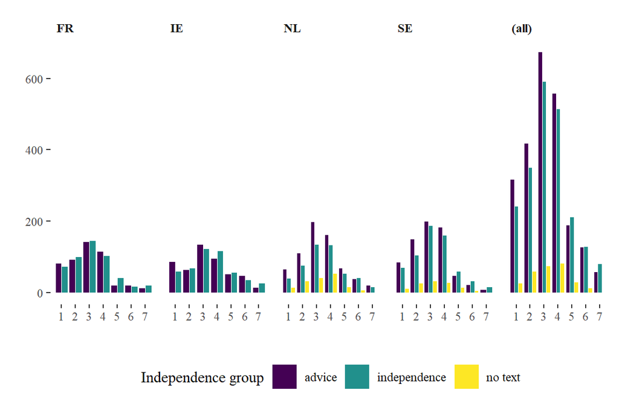

```r
pooled %>%
  ggplot(aes(x = perceived.independence.reversed, fill = experimental.group)) +
  geom_bar(width = 0.9, position = position_dodge()) + scale_y_continuous(name="") +
  scale_x_continuous(name="", breaks = 1:7) + scale_fill_manual(name = "Independence group") +  scale_fill_viridis_d(name = "Independence group") + facet_grid(~country, margins = T) + theme_tufte() + theme(strip.text = element_text(hjust = 0, face = "bold"),
    legend.position="bottom",
    aspect.ratio = 2.5)
```

## 6.3 T-test

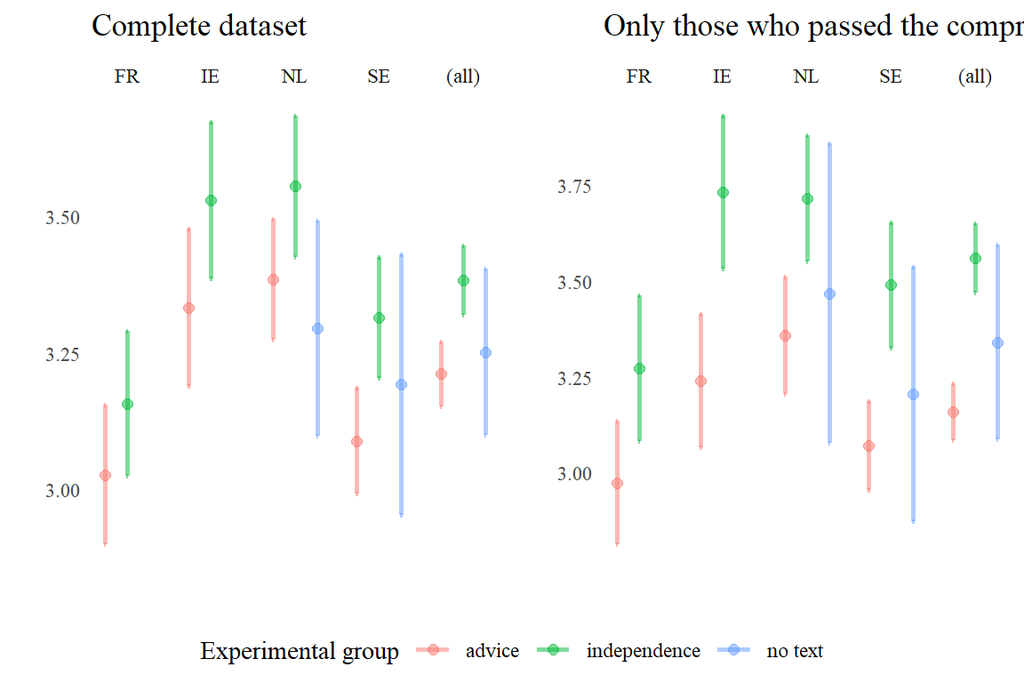

```r
ggarrange(pooled  %>% ggplot(aes(x = experimental.group, y = perceived.independence.reversed, color = experimental.group)) +
      stat_summary(fun.data = mean_cl_normal, geom = "errorbar", alpha = 0.5, width = 0.1, size = 1, position = position_dodge(0.5)) + labs(color ='Experimental group', x = "", y = "", title = "Complete dataset") +
    stat_summary(fun = mean, geom = "point", alpha = 0.5, size = 2 , position = position_dodge(0.5)) +  facet_grid(.~country, margins = TRUE) +  theme_tufte() + theme(axis.text.x = element_blank(), axis.ticks = element_blank()),

    pooled %>% filter(comprehension.check.failed == "passed") %>% ggplot(aes(x = experimental.group, y = perceived.independence.reversed, color = experimental.group)) +
      stat_summary(fun.data = mean_cl_normal, geom = "errorbar", alpha = 0.5, width = 0.1, size = 1, position = position_dodge(0.5)) + labs(color ='Experimental group', x = "", y = "", title = "Only those who passed the comprehension check") +
    stat_summary(fun = mean, geom = "point", alpha = 0.5, size = 2 , position = position_dodge(0.5)) +  facet_grid(.~country, margins = TRUE) +  theme_tufte() + theme(axis.text.x = element_blank(), axis.ticks = element_blank()), nrow = 1, common.legend =  TRUE, legend = "bottom")
```

### 6.3.1 With complete dataset (only advice/independence)

```r
tadaa_t.test(data = pooled.experiment, response = perceived.independence.reversed, group = experimental.group, print = "markdown")
```

Table 1: **Welch Two Sample t-test** with alternative hypothesis: $\mu_1 \neq \mu_2$

| Diff | $\mu_1$ advice | $\mu_2$ independence | t | SE | df | $CI_{95\%}$ | p | Cohen's d |
| --- | --- | --- | --- | --- | --- | --- | --- | --- |
| -0.17 | 3.21 | 3.38 | -3.86 | 0.04 | 4382.66 | (-0.26 - -0.08) | < .001 | -0.12 |

### 6.3.2 With those who failed the comprehension check filtered out (only advice/independence)

```r
tadaa_t.test(data = pooled.experiment.check, response = perceived.independence.reversed, group = experimental.group, print = "markdown")
```

Table 2: **Welch Two Sample t-test** with alternative hypothesis: $\mu_1 \neq \mu_2$

| Diff | $\mu_1$ advice | $\mu_2$ independence | t | SE | df | $CI_{95\%}$ | p | Cohen's d |
| --- | --- | --- | --- | --- | --- | --- | --- | --- |
| -0.4 | 3.16 | 3.56 | -6.78 | 0.06 | 2463.44 | (-0.52 - -0.29) | < .001 | -0.27 |

# 7 Time

## 7.1 Survey duration

### 7.1.1 Histogram

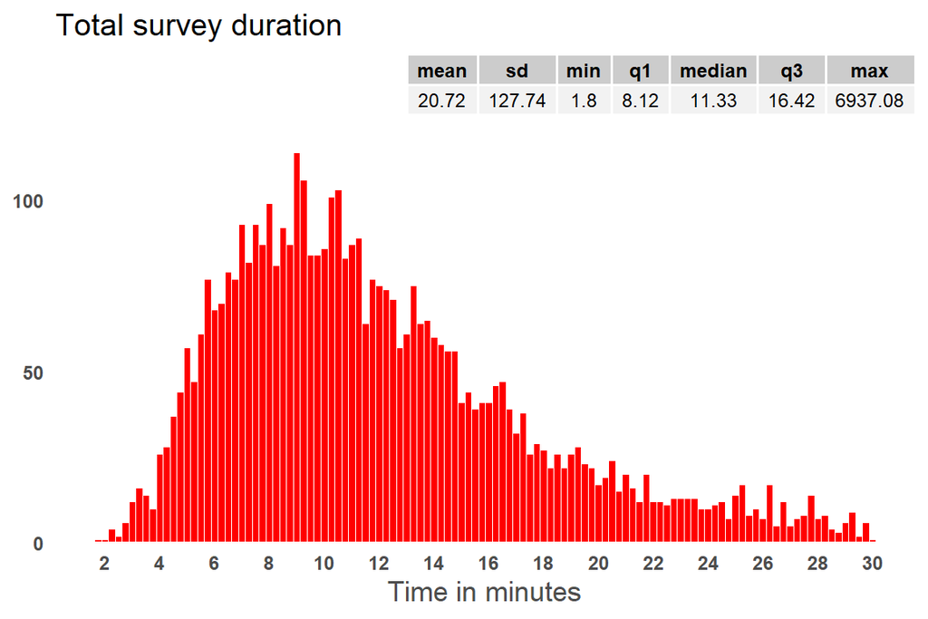

```r
pooled %>% filter(duration < 30) %>%
plot_frq((duration),
        geom.colors = scales::alpha("red",0.8),
        type = "hist",
        geom.size = 0.25) +
  theme(axis.text = element_text(face = "bold",  size= 9)) + labs(title = "Total survey duration") +  scale_x_continuous(name="Time in minutes", breaks = seq(0,30, 2)) +  scale_y_continuous(expand = expansion(c(0, 0.25))) + annotate(geom = "table", x = Inf, y = Inf, label = list(table.duration))
```

## 7.2 Do participants read the information about the case?

### 7.2.1 Page submission - introduction of case

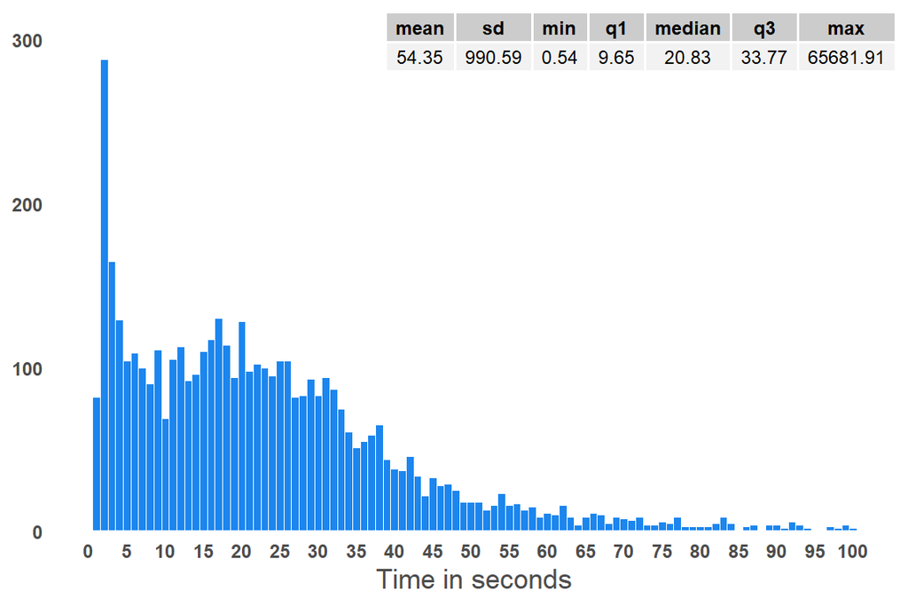

```r
pooled %>% filter(intro.submit < 100) %>%
plot_frq((intro.submit),
        geom.colors = scales::alpha("dodgerblue2",0.8),
        type = "hist",
        geom.size = 1) +
  theme(axis.text = element_text(face = "bold",  size= 9)) +
  scale_x_continuous(name="Time in seconds",breaks = seq(0,100,5)) +   scale_y_continuous(expand = expansion(c(0, 0.1))) + annotate(geom = "table", x = Inf, y = Inf, label = list(table.intro.submit))
```

### 7.2.2 Page submission - manipulation

*Histogram*

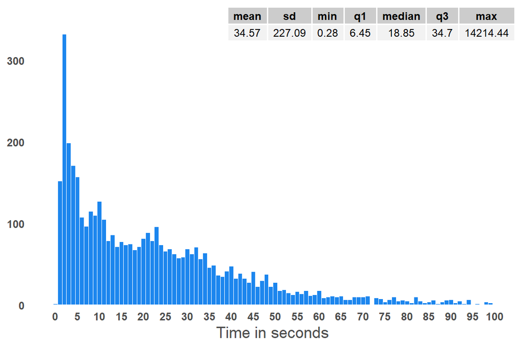

```r
pooled %>% filter(manipulation.submit < 100) %>%
plot_frq((manipulation.submit),
        geom.colors = scales::alpha("dodgerblue2",0.8),
        type = "hist",
        geom.size = 1) +
  theme(axis.text = element_text(face = "bold",  size= 9)) +
  scale_x_continuous(name="Time in seconds",breaks = seq(0,100,5)) +   scale_y_continuous(expand = expansion(c(0, 0.1))) + annotate(geom = "table", x = Inf, y = Inf, label = list(table.manipulation.submit))
```

*Difference in perceived independence with 30 seconds as cut-off point + number of cases per group*

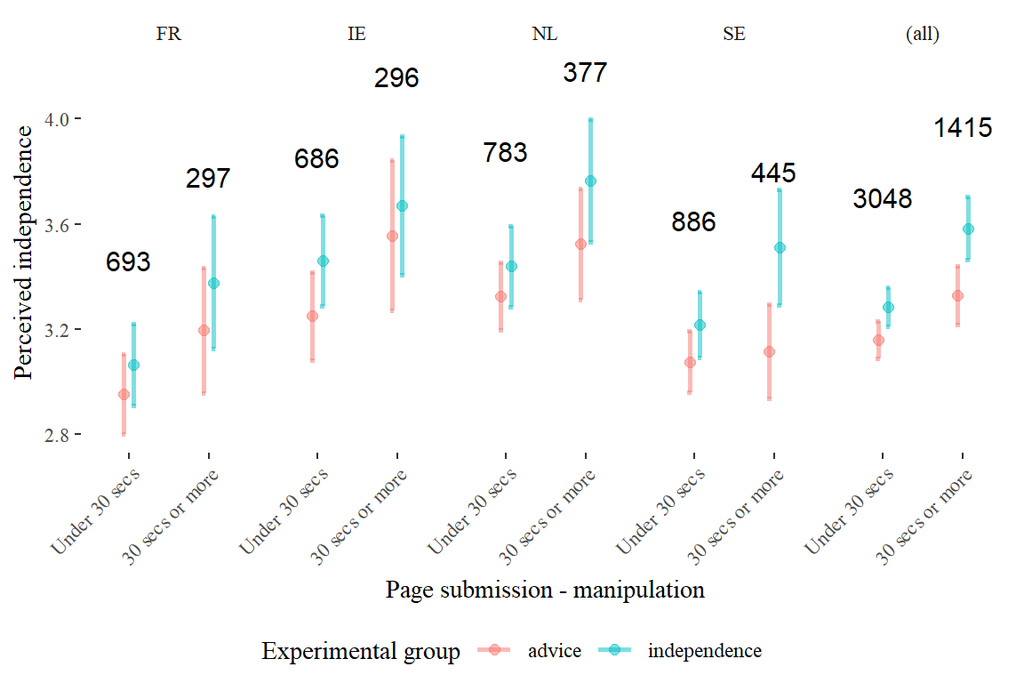

```r
give.n <- function(x){
  return(c(y = mean(x)*1.15, label = length(x)))
}

t8 <- pooled.experiment  %>% ggplot(aes(x = manipulation.submit.30,y = perceived.independence.reversed, color = experimental.group)) +
      stat_summary(fun.data = mean_cl_normal, geom = "errorbar", alpha = 0.5, width = 0.1, size = 1, position = position_dodge(0.25)) + labs(color ='Experimental group', x = "Page submission - manipulation", y = "Perceived independence") +
    stat_summary(fun = mean, geom = "point", alpha = 0.5, size = 2 , position=position_dodge(0.25)) +  facet_grid(. ~ country, margins = TRUE) +
  stat_summary(fun.data = give.n, geom = "text", fun = median, size = 4, col = "black") + theme_tufte() + theme(axis.text.x = element_text(angle = 45, hjust = 1))

ggarrange(t8, common.legend = TRUE, legend = "bottom")
```

*Broken down in quartiles per counry and total*

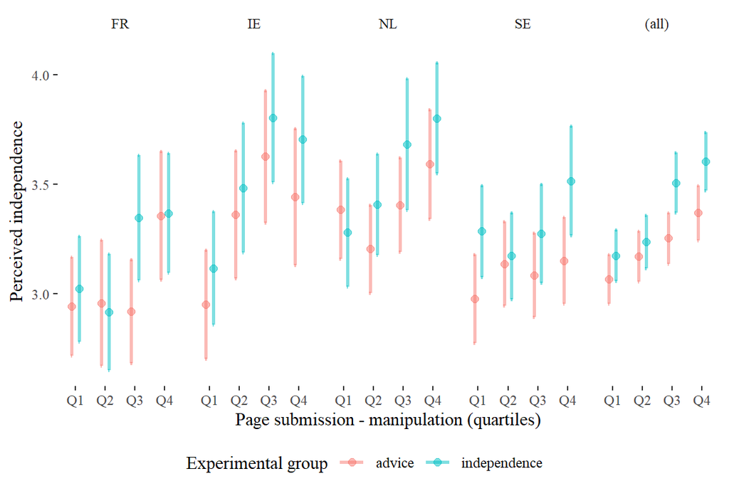

```r
t9 <- pooled.experiment  %>% ggplot(aes(x = manipulation.submit.quartile,y = perceived.independence.reversed, color = experimental.group)) +
      stat_summary(fun.data = mean_cl_normal, geom = "errorbar", alpha = 0.5, width = 0.1, size = 1, position = position_dodge(0.5)) + labs(color ='Experimental group', x = "Page submission - manipulation (quartiles)", y = "Perceived independence") +
    stat_summary(fun = mean, geom = "point", alpha = 0.5, size = 2 , position=position_dodge(0.5)) +  facet_grid(. ~ country, margins = TRUE) +  theme_tufte()

ggarrange(t9, common.legend = TRUE, legend = "bottom")
```

### 7.2.3 Page submission - EMA’s decision

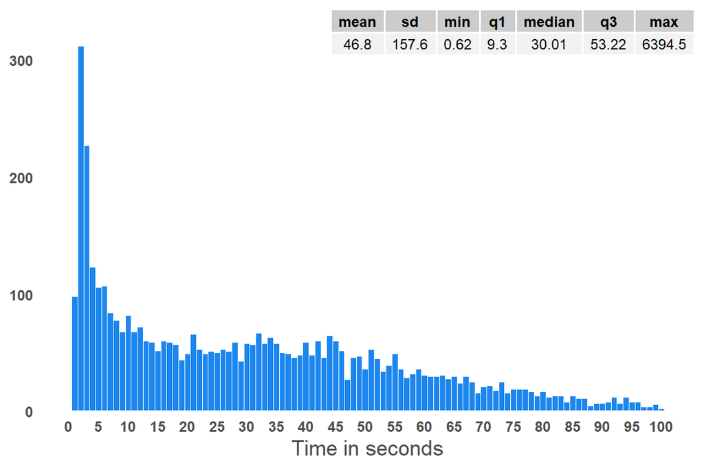

```r
pooled %>% filter(decision.submit < 100) %>%
plot_frq((decision.submit),
        geom.colors = scales::alpha("dodgerblue2",0.8),
        type = "hist",
        geom.size = 1) +
  theme(axis.text = element_text(face = "bold",  size= 9)) +
  scale_x_continuous(name= "Time in seconds", breaks = seq(0,100,5)) +   scale_y_continuous(expand = expansion(c(0, 0.1))) + annotate(geom = "table", x = Inf, y = Inf, label = list(table.decision.submit))
```

## 7.3 Time and …

*…Failing the comprehension check*

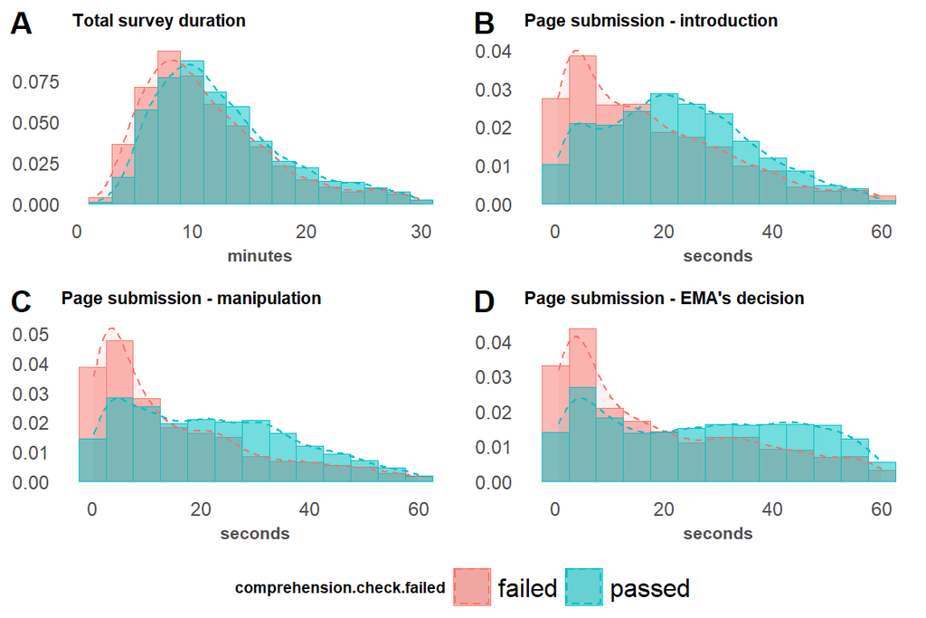

```r
t10 <- pooled.experiment %>% filter(duration < 30) %>% drop_na(comprehension.check.failed) %>%
  ggplot(aes(x= duration, color = comprehension.check.failed, fill = comprehension.check.failed)) + geom_histogram(aes(y=..density..), alpha=0.5, position="identity", binwidth = 2) +
 geom_density(alpha= .1, linetype= "dashed") + labs(title = "Total survey duration", x = "minutes") + theme(axis.title.y = element_blank(), title = element_text(size = 7, face = "bold"),  axis.text = element_text(size = 9))

t11  <- pooled.experiment %>% filter(intro.submit < 60) %>% drop_na(comprehension.check.failed) %>% ggplot(aes(x= intro.submit, color = comprehension.check.failed, fill = comprehension.check.failed)) + geom_histogram(aes(y=..density..), alpha=0.5, position="identity", binwidth = 5) +
 geom_density(alpha= .1, linetype= "dashed") + labs(title = "Page submission - introduction", x = "seconds") + theme(axis.title.y = element_blank(), title = element_text(size = 7, face = "bold"),  axis.text = element_text(size = 9))

t12 <- pooled.experiment %>% filter(manipulation.submit < 60) %>% drop_na(comprehension.check.failed) %>% ggplot(aes(x=manipulation.submit, color = comprehension.check.failed, fill = comprehension.check.failed)) + geom_histogram(aes(y=..density..), alpha=0.5, position="identity", binwidth = 5) + geom_density(alpha= .1, linetype= "dashed") + labs(title = "Page submission - manipulation", x = "seconds") + theme(axis.title.y = element_blank(), title = element_text(size = 7, face = "bold"),  axis.text = element_text(size = 9))

t13 <- pooled.experiment %>% filter(decision.submit < 60) %>% drop_na(comprehension.check.failed) %>% ggplot(aes(x=decision.submit, color =comprehension.check.failed, fill = comprehension.check.failed)) +
 geom_histogram(aes(y=..density..), alpha=0.5, position="identity", binwidth = 5) +
 geom_density(alpha= .1, linetype= "dashed") + labs(title = "Page submission - EMA's decision", x = "seconds") + theme(axis.title.y = element_blank(), title = element_text(size = 7, face = "bold"),  axis.text = element_text(size = 9))

ggarrange(t10, t11, t12, t13, nrow = 2, ncol = 2, labels="AUTO", legend = "bottom", common.legend = TRUE)
```

```r
# Change legend title
```

*…experimental groups*

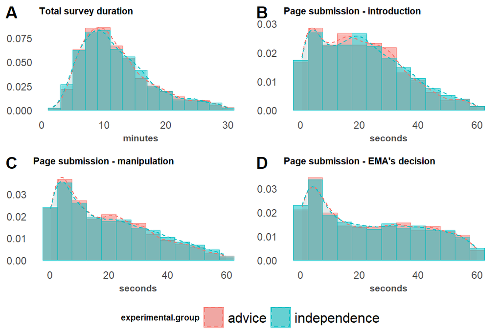

```r
t14 <- pooled.experiment %>% filter(duration < 30) %>% ggplot(aes(x= duration, color = experimental.group, fill = experimental.group)) + geom_histogram(aes(y=..density..), alpha=0.5, position="identity", binwidth = 2) +
 geom_density(alpha= .1, linetype= "dashed") + labs(title = "Total survey duration", x = "minutes") + theme(axis.title.y = element_blank(), title = element_text(size = 7, face = "bold"),  axis.text = element_text(size = 9))

t15  <- pooled.experiment %>% filter(intro.submit < 60) %>% ggplot(aes(x= intro.submit, color = experimental.group, fill = experimental.group)) + geom_histogram(aes(y=..density..), alpha=0.5, position="identity", binwidth = 5) +
 geom_density(alpha= .1, linetype= "dashed") + labs(title = "Page submission - introduction", x = "seconds") + theme(axis.title.y = element_blank(), title = element_text(size = 7, face = "bold"),  axis.text = element_text(size = 9))

t16 <- pooled.experiment %>% filter(manipulation.submit < 60) %>% ggplot(aes(x=manipulation.submit, color = experimental.group, fill = experimental.group)) + geom_histogram(aes(y=..density..), alpha=0.5, position="identity", binwidth = 5) + geom_density(alpha= .1, linetype= "dashed") + labs(title = "Page submission - manipulation", x = "seconds") + theme(axis.title.y = element_blank(), title = element_text(size = 7, face = "bold"),  axis.text = element_text(size = 9))

t17 <- pooled.experiment %>% filter(decision.submit < 60) %>% ggplot(aes(x=decision.submit, color = experimental.group, fill = experimental.group)) +
 geom_histogram(aes(y=..density..), alpha=0.5, position="identity", binwidth = 5) +
 geom_density(alpha= .1, linetype= "dashed") + labs(title = "Page submission - EMA's decision", x = "seconds", color = "Comprehension check") + theme(axis.title.y = element_blank(), title = element_text(size = 7, face = "bold"),  axis.text = element_text(size = 9))

ggarrange(t14, t15, t16, t17, nrow = 2, ncol = 2, labels="AUTO", legend = "bottom", common.legend = TRUE)
```

To check if there is a significant difference in the time indicators, I ran four t-test. Note that I removed cases that were 1.5 times outside the inter-quartile range (iqr), as these cases can be considered outliers. However, this approach is contested and other strategies may be more appropiate here.

*Survey duration*

```r
tadaa_t.test(data = out.duration, response = duration, group = experimental.group, print = "markdown")
```

Table 3: **Welch Two Sample t-test** with alternative hypothesis: $\mu_1 \neq \mu_2$

| Diff | $\mu_1$ advice | $\mu_2$ independence | t | SE | df | $CI_{95\%}$ | p | Cohen's d |
| --- | --- | --- | --- | --- | --- | --- | --- | --- |
| -0.04 | 11.92 | 11.95 | -0.22 | 0.17 | 4086.2 | (-0.37 - 0.3) | .827 | -0.01 |

*Page submission - Introduction*

```r
tadaa_t.test(data = out.intro.submit, response = intro.submit, group = experimental.group, print = "markdown")
```

Table 4: **Welch Two Sample t-test** with alternative hypothesis: $\mu_1 \neq \mu_2$

| Diff | $\mu_1$ advice | $\mu_2$ independence | t | SE | df | $CI_{95\%}$ | p | Cohen's d |
| --- | --- | --- | --- | --- | --- | --- | --- | --- |
| -0.54 | 21.18 | 21.72 | -1.15 | 0.47 | 4116.73 | (-1.46 - 0.38) | .251 | -0.04 |

*Page submission - manipulation*

```r
tadaa_t.test(data = out.manipulation.submit, response = manipulation.submit, group = experimental.group, print = "markdown")
```

Table 5: **Welch Two Sample t-test** with alternative hypothesis: $\mu_1 \neq \mu_2$

| Diff | $\mu_1$ advice | $\mu_2$ independence | t | SE | df | $CI_{95\%}$ | p | Cohen's d |
| --- | --- | --- | --- | --- | --- | --- | --- | --- |
| -0.9 | 20.5 | 21.4 | -1.68 | 0.54 | 4130.93 | (-1.96 - 0.15) | .093 | -0.05 |

*Page submission - decision*

```r
tadaa_t.test(data = out.decision.submit, response = decision.submit, group = experimental.group, print = "markdown")
```

Table 6: **Welch Two Sample t-test** with alternative hypothesis: $\mu_1 \neq \mu_2$

| Diff | $\mu_1$ advice | $\mu_2$ independence | t | SE | df | $CI_{95\%}$ | p | Cohen's d |
| --- | --- | --- | --- | --- | --- | --- | --- | --- |
| 0.91 | 32.92 | 32.02 | 1.1 | 0.82 | 4251.24 | (-0.71 - 2.52) | .271 | 0.03 |

*…interface (pc/mobile)*

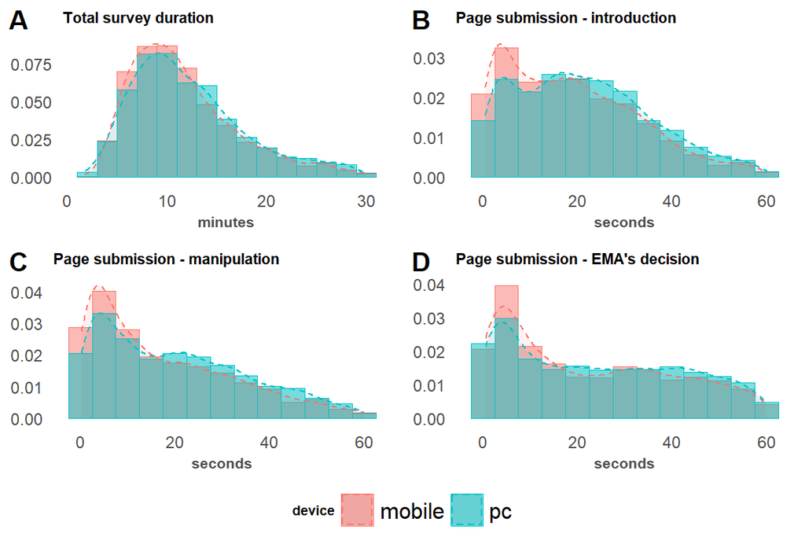

```r
t18 <- pooled %>% filter(duration < 30) %>% ggplot(aes(x= duration, color = device, fill = device)) + geom_histogram(aes(y=..density..), alpha=0.5, position="identity", binwidth = 2) +
 geom_density(alpha= .1, linetype= "dashed") + labs(title = "Total survey duration", x = "minutes") + theme(axis.title.y = element_blank(), title = element_text(size = 7, face = "bold"),  axis.text = element_text(size = 9))

t19 <- pooled %>% filter(intro.submit < 60) %>% ggplot(aes(x= intro.submit, color = device, fill = device)) + geom_histogram(aes(y=..density..), alpha=0.5, position="identity", binwidth = 5) +
 geom_density(alpha= .1, linetype= "dashed") + labs(title = "Page submission - introduction", x = "seconds") + theme(axis.title.y = element_blank(), title = element_text(size = 7, face = "bold"),  axis.text = element_text(size = 9))

t20 <- pooled %>% filter(manipulation.submit < 60) %>% ggplot(aes(x=manipulation.submit, color = device, fill = device)) + geom_histogram(aes(y=..density..), alpha=0.5, position="identity", binwidth = 5) + geom_density(alpha= .1, linetype= "dashed") + labs(title = "Page submission - manipulation", x = "seconds") + theme(axis.title.y = element_blank(), title = element_text(size = 7, face = "bold"),  axis.text = element_text(size = 9))

t21 <- pooled %>% filter(decision.submit < 60) %>% ggplot(aes(x=decision.submit, color = device, fill = device)) +
 geom_histogram(aes(y=..density..), alpha=0.5, position="identity", binwidth = 5) +
 geom_density(alpha= .1, linetype= "dashed") + labs(title = "Page submission - EMA's decision", x = "seconds") + theme(axis.title.y = element_blank(), title = element_text(size = 7, face = "bold"),  axis.text = element_text(size = 9))

ggarrange(t18, t19, t20, t21, nrow = 2, ncol = 2, labels="AUTO", legend = "bottom", common.legend = TRUE)
```

# 8 Interface (mobile/pc)

## 8.1 Distribution

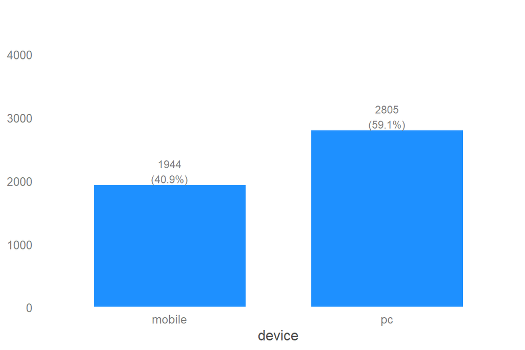

```r
pooled %>%
  plot_frq(device,
        ylim = c(0,nrow(pooled)),
        geom.colors = scales::alpha("dodgerblue1",0.8))+
  theme_blank()
```

## 8.2 Distribution of perceived independence for mobile/pc

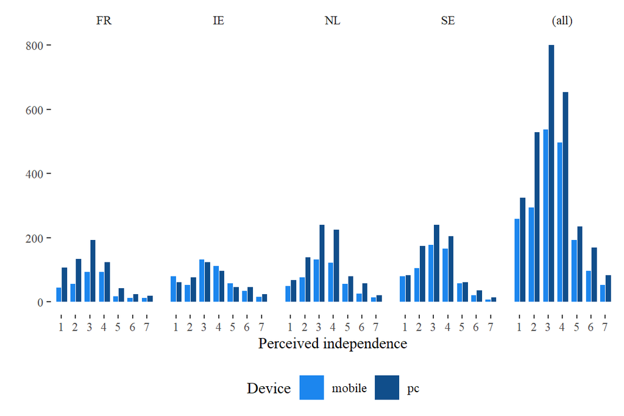

```r
pooled %>%
  ggplot(aes(x = perceived.independence.reversed, fill = device)) +
  geom_bar(width = 0.8, alpha = 1, position = position_dodge()) +  scale_x_continuous(name="Perceived independence", breaks = 1:7) + scale_y_continuous(name="") +  scale_fill_manual(name = "Device", values = c("dodgerblue2","dodgerblue4")) + facet_grid(~country, margins = TRUE) + theme_tufte() +  theme(legend.position="bottom")
```

```r
tadaa_t.test(data = pooled.experiment, response = perceived.independence.reversed, group = device, print = "markdown")
```

Table 7: **Welch Two Sample t-test** with alternative hypothesis: $\mu_1 \neq \mu_2$

| Diff | $\mu_1$ mobile | $\mu_2$ pc | t | SE | df | $CI_{95\%}$ | p | Cohen's d |
| --- | --- | --- | --- | --- | --- | --- | --- | --- |
| 0.03 | 3.31 | 3.28 | 0.71 | 0.05 | 3919.7 | (-0.06 - 0.12) | .48 | 0.02 |

# 9 Demography

## 9.1 Age

### 9.1.1 France

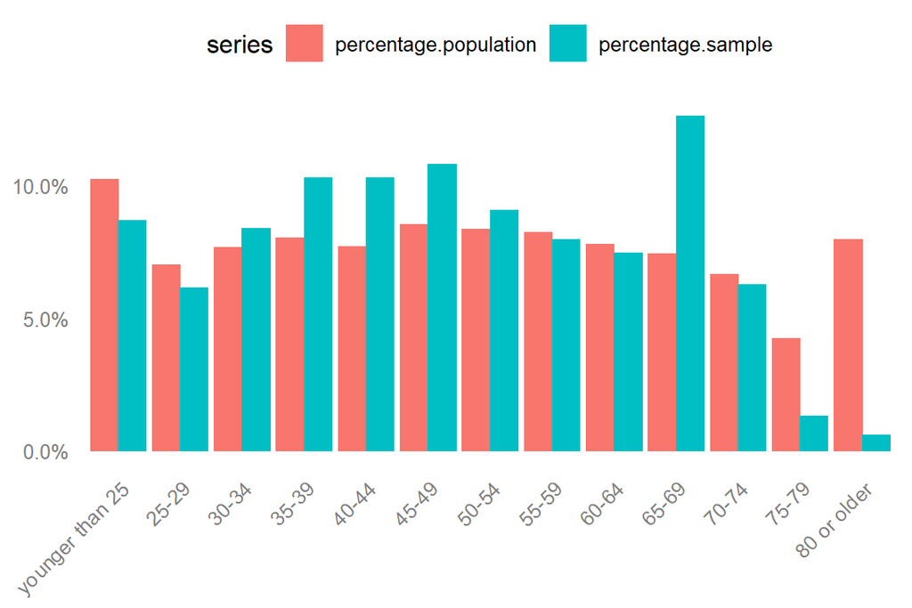

```r
age.population.FR <- read.csv("C:/Users/Thijs/surfdrive/COVID vaccine/git/FR/AGE_FR-08022021.csv")

age.population.FR <- age.population.FR %>% mutate(agecat = case_when(age < 25 ~ "younger than 25",
          age >= 25 & age < 30 ~ "25-29",
          age >= 30 & age < 35 ~ "30-34",
          age >= 35 & age < 40 ~ "35-39",
          age >= 40 & age < 45 ~ "40-44",
          age >= 45 & age < 50 ~ "45-49",
          age >= 50 & age < 55 ~ "50-54",
          age >= 55 & age < 60 ~ "55-59",
          age >= 60 & age < 65 ~ "60-64",
          age >= 65 & age < 70 ~ "65-69",
          age >= 70 & age < 75 ~ "70-74",
          age >= 75 & age < 80 ~ "75-79",
          age >= 80 ~ "80 or older"))

age.population.5.FR <- age.population.FR %>% group_by(agecat) %>% tally(count) %>% mutate(percentage = n / sum(n))

age.total.FR <- merge(age.population.5.FR, age.sample.FR, by.x = "agecat", by.y = "age.5")

age.total.FR <- age.total.FR %>%
  rename(age.category = agecat,
  count.population = n.x,
  count.sample = n.y,
  percentage.population = percentage.x,
  percentage.sample = percentage.y)

age.total.FR$age.category <- factor(age.total.FR$age.category, levels = c(
"younger than 25",
"25-29",           "30-34",           "35-39",
"40-44",           "45-49",           "50-54",
"55-59",           "60-64",           "65-69",
"70-74",           "75-79",           "80 or older"))

age.total.FR %>% select(age.category, percentage.population, percentage.sample) %>% reshape2::melt(id.vars = 'age.category', variable.name = 'series')  %>% ggplot(aes(age.category, value, colour = series, fill = series)) + geom_bar (stat="identity", width=0.9, position = position_dodge(width=0.9)) +
  theme_blank() + theme(legend.position="top", axis.text.x = element_text(angle = 45, hjust = 1), axis.title  = element_blank()) + scale_y_continuous(labels=scales::percent)
```

### 9.1.2 Netherlands

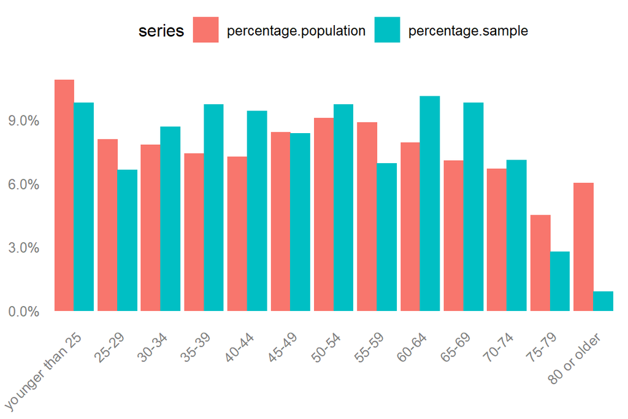

```r
age.population.5.NL <- read.csv("C:/Users/Thijs/surfdrive/COVID vaccine/git/NL/AGE_POPULATION_SEGMENTS_NL-22012021.csv")

age.total.NL <- merge(age.population.5.NL, age.sample.NL, by.x = "ï..age", by.y = "age.5")

age.total.NL <- age.total.NL %>%
  rename(age.category = ï..age,
  count.population = count,
  count.sample = n,
  percentage.population = percentage.x,
  percentage.sample = percentage.y)

age.total.NL$age.category <- factor(age.total.NL$age.category, levels = c(
"younger than 25",
"25-29",           "30-34",           "35-39",
"40-44",           "45-49",           "50-54",
"55-59",           "60-64",           "65-69",
"70-74",           "75-79",           "80 or older"))

age.total.NL %>% select(age.category, percentage.population, percentage.sample) %>% reshape2::melt(id.vars = 'age.category', variable.name = 'series')  %>% ggplot(aes(age.category, value, colour = series, fill = series)) + geom_bar (stat="identity", width=0.9, position = position_dodge(width=0.9)) +
  theme_blank() + theme(legend.position="top", axis.text.x = element_text(angle = 45, hjust = 1), axis.title  = element_blank()) + scale_y_continuous(labels=scales::percent)
```

### 9.1.3 Ireland

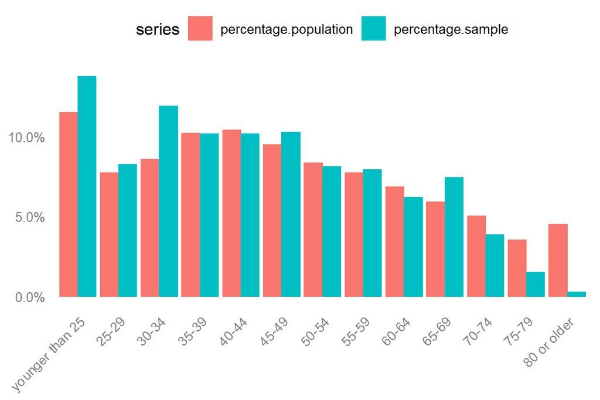

```r
age.population.5.IE <- read.csv("C:/Users/Thijs/surfdrive/COVID vaccine/git/EN/AGE_POPULATION_SEGMENTS_EN_25012021.csv")

age.total.IE <- merge(age.population.5.IE, age.sample.IE, by.x = "ï..age", by.y = "age.5")

age.total.IE  <- age.total.IE  %>%
  rename(age.category = ï..age,
  count.population = count,
  count.sample = n,
  percentage.population = percentage.x,
  percentage.sample = percentage.y)

age.total.IE$age.category <- factor(age.total.IE$age.category, levels = c(
"younger than 25",
"25-29",           "30-34",           "35-39",
"40-44",           "45-49",           "50-54",
"55-59",           "60-64",           "65-69",
"70-74",           "75-79",           "80 or older"))

age.total.IE  %>% select(age.category, percentage.population, percentage.sample) %>% reshape2::melt(id.vars = 'age.category', variable.name = 'series')  %>% ggplot(aes(age.category, value, colour = series, fill = series)) + geom_bar (stat="identity", width=0.9, position = position_dodge(width=0.9)) +
  theme_blank() + theme(legend.position="top", axis.text.x = element_text(angle = 45, hjust = 1), axis.title  = element_blank()) + scale_y_continuous(labels=scales::percent)
```

### 9.1.4 Sweden

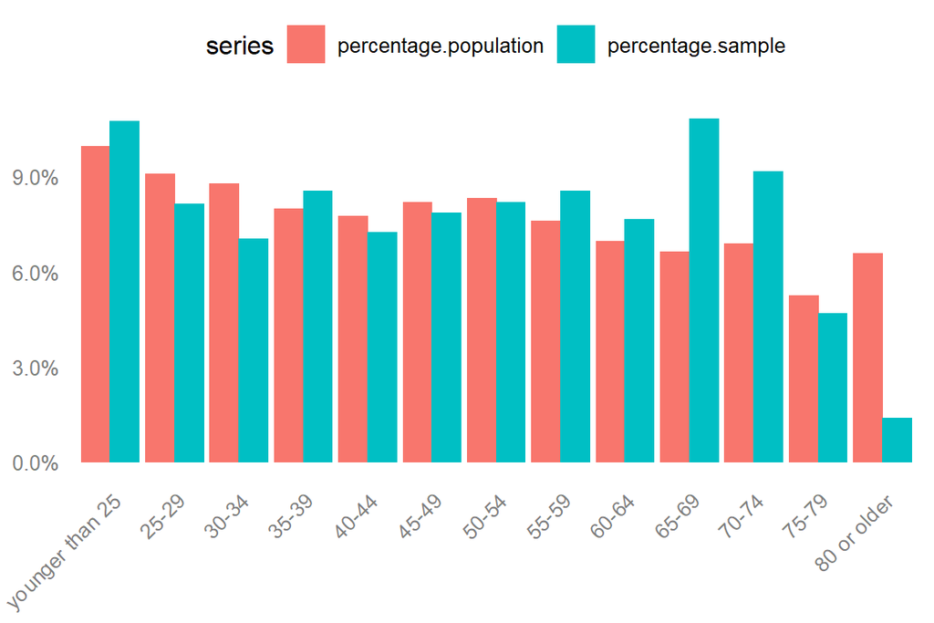

```r
age.population.5.SE <- read.csv("C:/Users/Thijs/surfdrive/COVID vaccine/git/SE/AGE_POPULATION_SEGMENTS_SE-22012021.csv")
age.total.SE <- merge(age.population.5.SE, age.sample.SE, by.x = "age", by.y = "age.5")

age.total.SE <- age.total.SE %>%
  rename(age.category = age,
  count.population = count,
  count.sample = n,
  percentage.population = percentage.x,
  percentage.sample = percentage.y)

age.total.SE$age.category <- factor(age.total.SE$age.category, levels = c(
"younger than 25",
"25-29",           "30-34",           "35-39",
"40-44",           "45-49",           "50-54",
"55-59",           "60-64",           "65-69",
"70-74",           "75-79",           "80 or older"))

age.total.SE %>% select(age.category, percentage.population, percentage.sample) %>% reshape2::melt(id.vars = 'age.category', variable.name = 'series')  %>% ggplot(aes(age.category, value, colour = series, fill = series)) + geom_bar (stat="identity", width=0.9, position = position_dodge(width=0.9)) +
  theme_blank() + theme(legend.position="top", axis.text.x = element_text(angle = 45, hjust = 1), axis.title  = element_blank()) + scale_y_continuous(labels=scales::percent)
```